# Group2_NBA_MVP_Model

## Leistungsnachweis Gruppenarbeit

### Gruppe 2 Dimitri Murri, Lukas Barth und Oliver Müller

murridim@students.zhaw.ch, barthluk@students.zhaw.ch, muellol7@students.zhaw.ch

### Objective

MVP der NBA für die Saison 23-24 vorhersagen.

```python
import requests
import os
import shutil
import pandas as pd
import warnings
warnings.simplefilter(action='ignore', category=FutureWarning)
warnings.filterwarnings('ignore', category=DeprecationWarning)

import time
import pymysql
import matplotlib.pyplot as plt
import seaborn as sns
import statsmodels.api as sm
import numpy as np
import matplotlib.pyplot as plt
import pandas as pd
import shap
from tqdm import tqdm

from nba_api.stats.endpoints import leaguedashplayerstats
from nba_api.stats.endpoints import playercareerstats
from nba_api.stats.static import players
from nba_api.stats.endpoints import playergamelog
from nba_api.stats.endpoints import commonplayerinfo
from nba_api.stats.static import players
from sklearn.ensemble import RandomForestRegressor
from sklearn.linear_model import LinearRegression
from sklearn.metrics import mean_absolute_error
from sklearn.metrics import r2_score


from selenium import webdriver
from selenium.webdriver.common.keys import Keys
from bs4 import BeautifulSoup
from sklearn.feature_selection import mutual_info_regression

#!pip install mysql-connector-python
```

#### (1) Datenerhebung mittels Web Scraping UND Web API

Datenerhebung mittels Web Scraping

```python
# scrape the data, can be only run a few times a day before getting blocked
'''
url_start = "https://www.basketball-reference.com/awards/awards_{}.html"

for year in years:
    url = url_start.format(year)

    data = requests.get(url)

    with open("mvp/{}.html".format(year), "w+") as f:
        f.write(data.text)
'''
```

```
'\nurl_start = "https://www.basketball-reference.com/awards/awards_{}.html"\n\nfor year in years:\n    url = url_start.format(year)\n    \n    data = requests.get(url)\n    \n    with open("mvp/{}.html".format(year), "w+") as f:\n        f.write(data.text)\n'
```

```python
"""
Reads an HTML file containing MVP data for the year 2022 and extracts the relevant information as an example.

Returns:
    DataFrame: A pandas DataFrame containing the MVP data for the year 2022.
"""

with open("mvp/2022.html") as f:
    page = f.read()

soup = BeautifulSoup(page, 'html.parser')
soup.find('tr', class_="over_header").decompose()

#Check data for 2022
mvp_table = soup.find_all(id="mvp")

mvp_2022 = pd.read_html(str(mvp_table))[0]
mvp_2022.head()
```

|  | Rank | Player | Age | Tm | First | Pts Won | Pts Max | Share | G | MP | PTS | TRB | AST | STL | BLK | FG% | 3P% | FT% | WS | WS/48 |
| --- | --- | --- | --- | --- | --- | --- | --- | --- | --- | --- | --- | --- | --- | --- | --- | --- | --- | --- | --- | --- |
| 0 | 1 | Nikola Jokić | 26 | DEN | 65.0 | 875.0 | 1000 | 0.875 | 74 | 33.5 | 27.1 | 13.8 | 7.9 | 1.5 | 0.9 | 0.583 | 0.337 | 0.810 | 15.2 | 0.296 |
| 1 | 2 | Joel Embiid | 27 | PHI | 26.0 | 706.0 | 1000 | 0.706 | 68 | 33.8 | 30.6 | 11.7 | 4.2 | 1.1 | 1.5 | 0.499 | 0.371 | 0.814 | 12.0 | 0.252 |
| 2 | 3 | Giannis Antetokounmpo | 27 | MIL | 9.0 | 595.0 | 1000 | 0.595 | 67 | 32.9 | 29.9 | 11.6 | 5.8 | 1.1 | 1.4 | 0.553 | 0.293 | 0.722 | 12.9 | 0.281 |
| 3 | 4 | Devin Booker | 25 | PHO | 0.0 | 216.0 | 1000 | 0.216 | 68 | 34.5 | 26.8 | 5.0 | 4.8 | 1.1 | 0.4 | 0.466 | 0.383 | 0.868 | 7.6 | 0.156 |
| 4 | 5 | Luka Dončić | 22 | DAL | 0.0 | 146.0 | 1000 | 0.146 | 65 | 35.4 | 28.4 | 9.1 | 8.7 | 1.2 | 0.6 | 0.457 | 0.353 | 0.744 | 7.6 | 0.159 |

Datenerhebung mittels Web API

```python
# Load the data of all players
players_list = players.get_players()

# Beispiel: Spielerdaten für Nikola Jokić
jokic = [player for player in players_list if player['full_name'] == 'Nikola Jokic'][0]
jokic_id = jokic['id']

# Nikola Jokićs Spieler-Log für eine Saison abrufen
log = playergamelog.PlayerGameLog(player_id=jokic_id, season='2023')
df = log.get_data_frames()[0]  # DataFrame mit den Daten

df.head()
```

|  | SEASON_ID | Player_ID | Game_ID | GAME_DATE | MATCHUP | WL | MIN | FGM | FGA | FG_PCT | ... | DREB | REB | AST | STL | BLK | TOV | PF | PTS | PLUS_MINUS | VIDEO_AVAILABLE |
| --- | --- | --- | --- | --- | --- | --- | --- | --- | --- | --- | --- | --- | --- | --- | --- | --- | --- | --- | --- | --- | --- |
| 0 | 22023 | 203999 | 0022301164 | APR 10, 2024 | DEN vs. MIN | W | 38 | 16 | 20 | 0.800 | ... | 9 | 11 | 7 | 3 | 0 | 2 | 5 | 41 | 6 | 1 |
| 1 | 22023 | 203999 | 0022301154 | APR 09, 2024 | DEN @ UTA | W | 34 | 12 | 20 | 0.600 | ... | 8 | 13 | 7 | 3 | 1 | 5 | 2 | 28 | 23 | 1 |
| 2 | 22023 | 203999 | 0022301130 | APR 06, 2024 | DEN vs. ATL | W | 31 | 6 | 13 | 0.462 | ... | 13 | 14 | 11 | 2 | 0 | 4 | 1 | 19 | 19 | 1 |
| 3 | 22023 | 203999 | 0022301114 | APR 04, 2024 | DEN @ LAC | L | 40 | 14 | 24 | 0.583 | ... | 16 | 17 | 10 | 0 | 0 | 5 | 2 | 36 | 12 | 1 |
| 4 | 22023 | 203999 | 0022301099 | APR 02, 2024 | DEN vs. SAS | W | 38 | 18 | 32 | 0.563 | ... | 12 | 16 | 6 | 1 | 2 | 4 | 2 | 42 | 5 | 1 |

5 rows × 27 columns

#### (2) Datenaufbereitung (z.B. Entfernen NAs und Duplikate, Erstellen neuer Variablen, Anreicherung der Daten, ...)

Datenaufbereitung in Dataframe

```python
years = list(range(1990,2023))
#years = [ 2016]

dfs = []
for year in years:
    with open("mvp/{}.html".format(year)) as f:
        page = f.read()

    soup = BeautifulSoup(page, 'html.parser')
    soup.find('tr', class_="over_header").decompose()
    mvp_table = soup.find_all(id="mvp")[0]
    mvp_df = pd.read_html(str(mvp_table))[0]
    mvp_df["Year"] = year
    dfs.append(mvp_df)

mvps = pd.concat(dfs)

mvps.head()
```

|  | Rank | Player | Age | Tm | First | Pts Won | Pts Max | Share | G | MP | ... | TRB | AST | STL | BLK | FG% | 3P% | FT% | WS | WS/48 | Year |
| --- | --- | --- | --- | --- | --- | --- | --- | --- | --- | --- | --- | --- | --- | --- | --- | --- | --- | --- | --- | --- | --- |
| 0 | 1 | Magic Johnson | 30 | LAL | 27.0 | 636.0 | 920 | 0.691 | 79 | 37.2 | ... | 6.6 | 11.5 | 1.7 | 0.4 | 0.480 | 0.384 | 0.890 | 16.5 | 0.270 | 1990 |
| 1 | 2 | Charles Barkley | 26 | PHI | 38.0 | 614.0 | 920 | 0.667 | 79 | 39.1 | ... | 11.5 | 3.9 | 1.9 | 0.6 | 0.600 | 0.217 | 0.749 | 17.3 | 0.269 | 1990 |
| 2 | 3 | Michael Jordan | 26 | CHI | 21.0 | 564.0 | 920 | 0.613 | 82 | 39.0 | ... | 6.9 | 6.3 | 2.8 | 0.7 | 0.526 | 0.376 | 0.848 | 19.0 | 0.285 | 1990 |
| 3 | 4 | Karl Malone | 26 | UTA | 2.0 | 214.0 | 920 | 0.233 | 82 | 38.1 | ... | 11.1 | 2.8 | 1.5 | 0.6 | 0.562 | 0.372 | 0.762 | 15.9 | 0.245 | 1990 |
| 4 | 5 | Patrick Ewing | 27 | NYK | 1.0 | 162.0 | 920 | 0.176 | 82 | 38.6 | ... | 10.9 | 2.2 | 1.0 | 4.0 | 0.551 | 0.250 | 0.775 | 13.5 | 0.205 | 1990 |

5 rows × 21 columns

#### NANs prüfen

```python
print(mvps.isna().sum())
```

```
Rank        0
Player      0
Age         0
Tm          0
First       0
Pts Won     0
Pts Max     0
Share       0
G           0
MP          0
PTS         0
TRB         0
AST         0
STL         0
BLK         0
FG%         0
3P%        11
FT%         0
WS          0
WS/48       0
Year        0
dtype: int64
```

Bei 3P% gibt es NANs, anhand einer Stichprobe vom Spieler Gobert prüfen ob NAN korrekt ist, dies wird mit einem Vergleich aus den Daten aus der API gemacht. Gemäss API hat Gobert in der Saison keinen einzigen 3-Punkte-Wurf gemacht, was mit den Daten aus der MVP-Tabelle übereinstimmt. Deshalb gehen wir davon aus, dass die Nullwerte in der MVP-Tabelle korrekt sind und keine fehlenden Werte darstellen

```python
# Finde die Zeilen, in denen '3P%' Null ist
null_3p_pct_rows = mvps[mvps['3P%'].isnull()]

# Die Spieler, die in diesen Zeilen aufgeführt sind, haben effektiv keinen Wurf ausserhalb der 3-Punkte-Linie gemacht
print(null_3p_pct_rows)

# Prüfen  ob die Daten aus der API dasselbe aussagen anhand Stichprobe von Goberz
gobert = [player for player in players_list if player['full_name'] == 'Rudy Gobert'][0]
gobert_id = gobert['id']

log_gobert_19 = playergamelog.PlayerGameLog(player_id=gobert_id, season='2018')
df_gobert_19 = log_gobert_19.get_data_frames()[0]  # DataFrame mit den Daten

print(df_gobert_19)

total_3pa = df_gobert_19['FG3A'].sum()  # Gesamtanzahl der Dreipunktewurfversuche
total_3pm = df_gobert_19['FG3M'].sum()  # Gesamtanzahl der getroffenen Dreipunktewürfe
gobert_3p_pct = (total_3pm / total_3pa) if total_3pa > 0 else 0

print(f"Rudy Gobert's career 3P%: {gobert_3p_pct:.3f}")
```

```
   Rank            Player  Age   Tm  First  Pts Won  Pts Max  Share   G    MP  \
12  13T   Dikembe Mutombo   30  ATL    0.0      4.0     1150  0.003  80  37.2
3     4  Shaquille O'Neal   25  LAL    1.0    311.0     1160  0.268  60  36.3
15  15T     Anthony Mason   34  MIA    0.0      1.0     1240  0.001  80  40.7
16  16T       Elton Brand   22  LAC    0.0      1.0     1260  0.001  80  37.8
4     5  Shaquille O'Neal   30  LAL    3.0    126.0     1190  0.106  67  37.8
5     6  Shaquille O'Neal   31  LAL    0.0    178.0     1230  0.145  67  36.8
1     2  Shaquille O'Neal   32  MIA   58.0   1032.0     1270  0.813  73  34.1
13  14T        P.J. Brown   35  NOH    0.0      1.0     1270  0.001  82  34.4
8    9T     Carlos Boozer   25  UTA    0.0      7.0     1290  0.005  74  34.6
11  12T  Shaquille O'Neal   34  MIA    0.0      3.0     1290  0.002  40  28.4
10  11T       Rudy Gobert   26  UTA    0.0      1.0     1010  0.001  81  31.8

    ...   TRB  AST  STL  BLK    FG%  3P%    FT%    WS  WS/48  Year
12  ...  11.6  1.4  0.6  3.3  0.527  NaN  0.705  11.3  0.183  1997
```

[output cut: 53 more lines]

#### Anreicherung der Daten aus dem WebScrping mit den Daten aus der API und Erstellung neuer Variablen

Einige relevanten Daten fehlen aus den gescrapten Daten. Da wir aber als Basis die Daten aus dem scraping verwenden wollten (da in der Realität nicht immer eine vollständige API verfügbar ist), haben wir die fehlenden Attribute anhand der nba_api ergänzt. Dazu gehöhren Daten den Spielern selbst sowieso ihre sog. Stats.

```python
mvps.reset_index(drop=True, inplace=True)

mvps['Nationality'] = ''
mvps['Position'] = ''
mvps['Weight_kg'] = ''
mvps['Height_cm'] = ''
mvps['DRAFT_NUMBER'] = ''
mvps['FGA'] = None
mvps['FGM'] = None
mvps['FTA'] = None
mvps['FTM'] = None
mvps['TOV'] = None
mvps['3PM'] = None
mvps['MIN'] = None
mvps['DREB'] = None
mvps['OREB'] = None

players_dict = players.get_players()

def replace_special_characters(name):
    replacements = {'ć': 'c', 'ó': 'o', 'č': 'c'}
    for original, replacement in replacements.items():
        name = name.replace(original, replacement)
    return name

# Update this dictionary for any known exceptions
# Smith is spelled differently in the API and the MVP data
known_exceptions = {
    "Steve Smith": "Steven Smith"
}

def height_to_cm(height_str):
    if pd.isna(height_str) or isinstance(height_str, float):
        return None
    try:
        feet, inches = height_str.split("-")  # Change the split character from "'" to "-"
        feet = int(feet)
        inches = int(inches)  # Since the inches part doesn't have any quotes to remove, no need for replace
        return (feet * 12 + inches) * 2.54
    except ValueError:
        # Handle the case where height is not in the "X-Y" format
        return None

def get_season_string(year):
    start_year = int(year)
    end_year = start_year + 1
    return f"{start_year}-{str(end_year)[2:]}"

def get_player_info(full_name, year):
    # Check if the name is a known exception and replace accordingly.
    full_name = known_exceptions.get(full_name, full_name)
    full_name = replace_special_characters(full_name)

    player_list = [player for player in players_dict if player['full_name'].lower() == full_name.lower()]

    for player in player_list:
        player_id = player['id']
        player_info = commonplayerinfo.CommonPlayerInfo(player_id=player_id).get_normalized_dict()
        player_info_data = player_info['CommonPlayerInfo'][0]
        if adjusted_year >= int(player_info_data['FROM_YEAR']) and adjusted_year <= int(player_info_data['TO_YEAR']):
            return (player_info_data['COUNTRY'],
                    player_info_data['POSITION'],
                    player_info_data['WEIGHT'],
                    player_info_data['HEIGHT'],
                    player_info_data['DRAFT_NUMBER'])


def get_player_stats(full_name, year):
    # Check if the name is a known exception and replace accordingly.
    full_name = known_exceptions.get(full_name, full_name)
    full_name = replace_special_characters(full_name)
    season_id = get_season_string(year)
    player_list = [player for player in players_dict if player['full_name'].lower() == full_name.lower()]
    for player in player_list:
        player_id = player['id']
        player_info_stats = playercareerstats.PlayerCareerStats(player_id=player_id).get_normalized_dict()
        player_info_stats_data = player_info_stats['SeasonTotalsRegularSeason'][0]

        for season_stats in player_info_stats['SeasonTotalsRegularSeason']:
            if season_stats['SEASON_ID'] == season_id:
                return (season_stats['FGA'],
                        season_stats['FGM'],
                        season_stats['FTA'],
                        season_stats['FTM'],
                        season_stats['TOV'],
                        season_stats['FG3M'],
                        season_stats['MIN'],
                        season_stats['DREB'],
                        season_stats['OREB'])

    print(f"No stats found for {full_name} in season {season_id}")


for index, row in mvps.iterrows():
    #if index >= 20:
    #    break
    adjusted_year = row['Year'] - 1
    nationality, position, weight, height, draft_number = get_player_info(row['Player'], adjusted_year)

    if nationality and position:
        mvps.at[index, 'Nationality'] = nationality
        mvps.at[index, 'Position'] = position
        mvps.at[index, 'Weight_kg'] = weight
        mvps.at[index, 'Height_cm'] = height
        mvps.at[index, 'DRAFT_NUMBER'] = draft_number

    else:
        print(f"No data found for player: {row['Player']} in year {row['Year']}")

    FGA, FGM, FTA, FTM, TOV, threePM, MIN, DREB, OREB= get_player_stats(row['Player'], adjusted_year)
    if FGA and FGM and FTA and FTM and TOV:
        mvps.at[index, 'FGA'] = int(FGA)
        mvps.at[index, 'FGM'] = int(FGM)
        mvps.at[index, 'FTA'] = int(FTA)
        mvps.at[index, 'FTM'] = int(FTM)
        mvps.at[index, 'TOV'] = int(TOV)
        mvps.at[index, '3PM'] = int(threePM)
        mvps.at[index, 'MIN'] = int(MIN)
        mvps.at[index, 'DREB'] = int(DREB)
        mvps.at[index, 'OREB'] = int(OREB)
    else:
        print(f"No stats found for player: {row['Player']} in year {row['Year']}")

# Convert height to centimeters
mvps['Height_cm'] = mvps['Height_cm'].apply(height_to_cm)

# Convert weight from pounds to kilograms
mvps['Weight_kg'] = pd.to_numeric(mvps['Weight_kg'], errors='coerce') / 2.20462

# Convert draft number to numeric type
mvps['DRAFT_NUMBER'] = pd.to_numeric(mvps['DRAFT_NUMBER'], errors='coerce').astype(pd.Int32Dtype())

# Set the proper data types for other columns
mvps['Nationality'] = mvps['Nationality'].astype('string')
mvps['Position'] = mvps['Position'].astype('string')

mvps['FGA'] = pd.to_numeric(mvps['FGA'], errors='coerce')
mvps['FGM'] = pd.to_numeric(mvps['FGM'], errors='coerce')
mvps['FTA'] = pd.to_numeric(mvps['FTA'], errors='coerce')
mvps['FTM'] = pd.to_numeric(mvps['FTM'], errors='coerce')
mvps['TOV'] = pd.to_numeric(mvps['TOV'], errors='coerce')
mvps['3PM'] = pd.to_numeric(mvps['3PM'], errors='coerce')
mvps['MIN'] = pd.to_numeric(mvps['MIN'], errors='coerce')
mvps['DREB'] = pd.to_numeric(mvps['DREB'], errors='coerce')
mvps['OREB'] = pd.to_numeric(mvps['OREB'], errors='coerce')

mvps.head()
```

|  | Rank | Player | Age | Tm | First | Pts Won | Pts Max | Share | G | MP | ... | DRAFT_NUMBER | FGA | FGM | FTA | FTM | TOV | 3PM | MIN | DREB | OREB |
| --- | --- | --- | --- | --- | --- | --- | --- | --- | --- | --- | --- | --- | --- | --- | --- | --- | --- | --- | --- | --- | --- |
| 0 | 1 | Magic Johnson | 30 | LAL | 27.0 | 636.0 | 920 | 0.691 | 79 | 37.2 | ... | 1 | 1138 | 546 | 637 | 567 | 289 | 106 | 2937 | 394 | 128 |
| 1 | 2 | Charles Barkley | 26 | PHI | 38.0 | 614.0 | 920 | 0.667 | 79 | 39.1 | ... | 5 | 1177 | 706 | 744 | 557 | 243 | 20 | 3085 | 548 | 361 |
| 2 | 3 | Michael Jordan | 26 | CHI | 21.0 | 564.0 | 920 | 0.613 | 82 | 39.0 | ... | 3 | 1964 | 1034 | 699 | 593 | 247 | 92 | 3197 | 422 | 143 |
| 3 | 4 | Karl Malone | 26 | UTA | 2.0 | 214.0 | 920 | 0.233 | 82 | 38.1 | ... | 13 | 1627 | 914 | 913 | 696 | 304 | 16 | 3122 | 679 | 232 |
| 4 | 5 | Patrick Ewing | 27 | NYK | 1.0 | 162.0 | 920 | 0.176 | 82 | 38.6 | ... | 1 | 1673 | 922 | 648 | 502 | 278 | 1 | 3165 | 658 | 235 |

5 rows × 35 columns

Advanced Stats berechnen wie zum Beispiel Box Plus/minus (BPM) und PER um später eine bessere Prediction machen zu können. Es gibt APIs welche auch diese Infos direkt hätten, hier wurde eine eigene Berechnung bevorzugt.

Für BPM daran orientiert: https://basketballstat.home.blog/2019/08/27/box-plus-minus-bpm/ Quelle für PER: https://bleacherreport.com/articles/113144-cracking-the-code-how-to-calculate-hollingers-per-without-all-the-mess

```python
mvps['Simplified_BPM'] = ((mvps['PTS'] + 0.5 * mvps['TRB'] + mvps['AST'] + 2 * (mvps['STL'] + mvps['BLK'])
                          - (mvps['FGA'] - mvps['FGM']) - 0.5 * (mvps['FTA'] - mvps['FTM']) - mvps['TOV']) / mvps['MP']) * -1

mvps['FT_Miss'] = mvps['FTA'] - mvps['FTM']
mvps['FG_Miss'] = mvps['FGA'] - mvps['FGM']
mvps['FT_Miss'] = pd.to_numeric(mvps['OREB'], errors='coerce')
mvps['FG_Miss'] = pd.to_numeric(mvps['DREB'], errors='coerce')

mvps['PER'] = (mvps['FGM'] * 85.910 + mvps['STL'] * 53.897 + mvps['STL'] * 51.757 + mvps['FTM'] * 46.845 + mvps['BLK'] * 39.190 +
       mvps['OREB'] * 39.190 + mvps['AST'] * 34.677 + mvps['DREB'] * 14.707 -
       mvps['FT_Miss'] * 20.091 - mvps['FG_Miss'] * 39.190 - mvps['TOV'] * 53.897) / mvps['MIN']

mvps.head()
```

|  | Rank | Player | Age | Tm | First | Pts Won | Pts Max | Share | G | MP | ... | FTM | TOV | 3PM | MIN | DREB | OREB | Simplified_BPM | FT_Miss | FG_Miss | PER |
| --- | --- | --- | --- | --- | --- | --- | --- | --- | --- | --- | --- | --- | --- | --- | --- | --- | --- | --- | --- | --- | --- |
| 0 | 1 | Magic Johnson | 30 | LAL | 27.0 | 636.0 | 920 | 0.691 | 79 | 37.2 | ... | 567 | 289 | 106 | 2937 | 394 | 128 | 23.513441 | 128 | 394 | 17.461418 |
| 1 | 2 | Charles Barkley | 26 | PHI | 38.0 | 614.0 | 920 | 0.667 | 79 | 39.1 | ... | 557 | 243 | 20 | 3085 | 548 | 361 | 19.632992 | 361 | 548 | 21.875431 |
| 2 | 3 | Michael Jordan | 26 | CHI | 21.0 | 564.0 | 920 | 0.613 | 82 | 39.0 | ... | 593 | 247 | 92 | 3197 | 422 | 143 | 30.247436 | 143 | 422 | 30.102761 |
| 3 | 4 | Karl Malone | 26 | UTA | 2.0 | 214.0 | 920 | 0.233 | 82 | 38.1 | ... | 696 | 304 | 16 | 3122 | 679 | 232 | 28.397638 | 232 | 679 | 26.530197 |
| 4 | 5 | Patrick Ewing | 27 | NYK | 1.0 | 162.0 | 920 | 0.176 | 82 | 38.6 | ... | 502 | 278 | 1 | 3165 | 658 | 235 | 27.351036 | 235 | 658 | 24.157661 |

5 rows × 39 columns

### (3) Speichern der Daten in einer Database wie MySQL oder PostgreSQL sowie SQL Abfragen aus dieser

```python
db = pymysql.connect(host="secondtest.cfis62ku07hb.eu-central-1.rds.amazonaws.com", user="admin", password="12345678")
```

```python
"""
This code selects the version of the database being used to show that the connection is working.
"""

cursor = db.cursor()
cursor.execute("select version()")
```

```
1
```

```python
"""
Creates a database named 'ads_project_group2' if it doesn't already exist.
"""
sql = '''create database if not exists ads_project_group2;'''
cursor.execute(sql)
cursor.connection.commit()
```

```python
sql = '''use ads_project_group2'''
cursor.execute(sql)
```

```
0
```

```python
# CREATE TABLE Anweisung für die Tabelle 'player_game_log'

create_table_query = '''
CREATE TABLE IF NOT EXISTS player_game_log (
    Player_ID INT,
    Season VARCHAR(7),
    Game_ID VARCHAR(15),
    Game_Date DATE,
    MATCHUP VARCHAR(15),
    WL CHAR(1),
    MIN INT,
    FGM INT,
    FGA INT,
    FG_PCT FLOAT,
    FG3M INT,
    FG3A INT,
    FG3_PCT FLOAT,
    FTM INT,
    FTA INT,
    FT_PCT FLOAT,
    OREB INT,
    DREB INT,
    REB INT,
    AST INT,
    STL INT,
    BLK INT,
    TOV INT,
    PF INT,
    PTS INT,
    PLUS_MINUS INT,
    VIDEO_AVAILABLE TINYINT,
    AST_TO_TOV_RATIO FLOAT
);
'''
#Added the column 'AST_TO_TOV_RATIO' to the table

cursor.execute(create_table_query)

# Commit (Bestätigen) Sie die Änderungen, falls erforderlich
db.commit()
#'''
```

```python
# Execute SQL query to show tables and check if it worked
sql = '''show tables'''
cursor.execute(sql)
cursor.fetchall()
```

```
(('player_game_log',),)
```

```python
# INSERT INTO Anweisung vorbereiten
def insert_player_game_log(player_game_log_df, player_id):

    # SQL insert statement
    insert_stmt = (
        "INSERT INTO player_game_log (Player_ID, Season, Game_ID, Game_Date, MATCHUP, WL, MIN, FGM, FGA, FG_PCT, FG3M, FG3A, FG3_PCT, FTM, FTA, FT_PCT, OREB, DREB, REB, AST, STL, BLK, TOV, PF, PTS, PLUS_MINUS, VIDEO_AVAILABLE, AST_TO_TOV_RATIO) "
        "VALUES (%s, %s, %s, %s, %s, %s, %s, %s, %s, %s, %s, %s, %s, %s, %s, %s, %s, %s, %s, %s, %s, %s, %s, %s, %s, %s, %s, %s)"
        )

    # Insert data into the table
    for index, row in player_game_log_df.iterrows():
        data = (
            row['Player_ID'],
            row['SEASON_ID'],  # Make sure this column name matches the one in your DataFrame
            row['Game_ID'],
            row['GAME_DATE'],
            row['MATCHUP'],
            row['WL'],
            row['MIN'],
            row['FGM'],
            row['FGA'],
            row['FG_PCT'],
            row['FG3M'],
            row['FG3A'],
            row['FG3_PCT'],
            row['FTM'],
            row['FTA'],
            row['FT_PCT'],
            row['OREB'],
            row['DREB'],
            row['REB'],
            row['AST'],
            row['STL'],
            row['BLK'],
            row['TOV'],
            row['PF'],
            row['PTS'],
            row['PLUS_MINUS'],
            row['VIDEO_AVAILABLE'],
            row['AST_TO_TOV_RATIO']

        )
        cursor.execute(insert_stmt, data)

        # Commit the transaction
    db.commit()
    print(cursor.rowcount, "records inserted successfully into player_game_log table")


# Add assist to turnover ratio
df['AST_TO_TOV_RATIO'] = df.apply(lambda x: x['AST'] / x['TOV'] if x['TOV'] > 0 else 0, axis=1)

#Game date muss formatiert werden, so dass es in der DB korrekt angezeigt wird und nicht als 0000-00-00
df['GAME_DATE'] = df['GAME_DATE'].astype(str)
correct_date_format = df['GAME_DATE'].str.match(r'^\d{4}-\d{2}-\d{2}$')
incorrect_dates = df[~correct_date_format]
print(incorrect_dates)
df['GAME_DATE'] = pd.to_datetime(df['GAME_DATE'], errors='coerce')

# Insert the data into SQL
insert_player_game_log(df, jokic_id)
```

```
   SEASON_ID  Player_ID     Game_ID     GAME_DATE      MATCHUP WL  MIN  FGM  \
0      22023     203999  0022301164  APR 10, 2024  DEN vs. MIN  W   38   16
1      22023     203999  0022301154  APR 09, 2024    DEN @ UTA  W   34   12
2      22023     203999  0022301130  APR 06, 2024  DEN vs. ATL  W   31    6
3      22023     203999  0022301114  APR 04, 2024    DEN @ LAC  L   40   14
4      22023     203999  0022301099  APR 02, 2024  DEN vs. SAS  W   38   18
..       ...        ...         ...           ...          ... ..  ...  ...
72     22023     203999  0022300123  NOV 01, 2023    DEN @ MIN  L   30   11
73     22023     203999  0022300110  OCT 30, 2023  DEN vs. UTA  W   35   12
74     22023     203999  0022300095  OCT 29, 2023    DEN @ OKC  W   30   12
75     22023     203999  0022300078  OCT 27, 2023    DEN @ MEM  W   35    8
76     22023     203999  0022300061  OCT 24, 2023  DEN vs. LAL  W   36   12

    FGA  FG_PCT  ...  REB  AST  STL  BLK  TOV  PF  PTS  PLUS_MINUS  \
0    20   0.800  ...   11    7    3    0    2   5   41           6
```

[output cut: 25 more lines]

```
1 records inserted successfully into player_game_log table
```

```python
cursor.execute("SELECT * FROM player_game_log")

# Hole alle Zeilen der Abfrage
rows = cursor.fetchall()

# Erstelle einen DataFrame aus den Abfrageergebnissen
columns = [desc[0] for desc in cursor.description]
all_data_jokic_df = pd.DataFrame(rows, columns=columns)

# Zeige den DataFrame an
all_data_jokic_df
```

|  | Player_ID | Season | Game_ID | Game_Date | MATCHUP | WL | MIN | FGM | FGA | FG_PCT | ... | REB | AST | STL | BLK | TOV | PF | PTS | PLUS_MINUS | VIDEO_AVAILABLE | AST_TO_TOV_RATIO |
| --- | --- | --- | --- | --- | --- | --- | --- | --- | --- | --- | --- | --- | --- | --- | --- | --- | --- | --- | --- | --- | --- |
| 0 | 203999 | 22023 | 0022301164 | 2024-04-10 | DEN vs. MIN | W | 38 | 16 | 20 | 0.800 | ... | 11 | 7 | 3 | 0 | 2 | 5 | 41 | 6 | 1 | 3.500000 |
| 1 | 203999 | 22023 | 0022301154 | 2024-04-09 | DEN @ UTA | W | 34 | 12 | 20 | 0.600 | ... | 13 | 7 | 3 | 1 | 5 | 2 | 28 | 23 | 1 | 1.400000 |
| 2 | 203999 | 22023 | 0022301130 | 2024-04-06 | DEN vs. ATL | W | 31 | 6 | 13 | 0.462 | ... | 14 | 11 | 2 | 0 | 4 | 1 | 19 | 19 | 1 | 2.750000 |
| 3 | 203999 | 22023 | 0022301114 | 2024-04-04 | DEN @ LAC | L | 40 | 14 | 24 | 0.583 | ... | 17 | 10 | 0 | 0 | 5 | 2 | 36 | 12 | 1 | 2.000000 |
| 4 | 203999 | 22023 | 0022301099 | 2024-04-02 | DEN vs. SAS | W | 38 | 18 | 32 | 0.563 | ... | 16 | 6 | 1 | 2 | 4 | 2 | 42 | 5 | 1 | 1.500000 |
| ... | ... | ... | ... | ... | ... | ... | ... | ... | ... | ... | ... | ... | ... | ... | ... | ... | ... | ... | ... | ... | ... |
| 72 | 203999 | 22023 | 0022300123 | 2023-11-01 | DEN @ MIN | L | 30 | 11 | 23 | 0.478 | ... | 10 | 3 | 0 | 0 | 5 | 0 | 25 | -19 | 1 | 0.600000 |
| 73 | 203999 | 22023 | 0022300110 | 2023-10-30 | DEN vs. UTA | W | 35 | 12 | 16 | 0.750 | ... | 10 | 11 | 0 | 2 | 1 | 3 | 27 | 13 | 1 | 11.000000 |
| 74 | 203999 | 22023 | 0022300095 | 2023-10-29 | DEN @ OKC | W | 30 | 12 | 16 | 0.750 | ... | 14 | 5 | 0 | 0 | 4 | 3 | 28 | 21 | 1 | 1.250000 |
| 75 | 203999 | 22023 | 0022300078 | 2023-10-27 | DEN @ MEM | W | 35 | 8 | 14 | 0.571 | ... | 12 | 7 | 1 | 1 | 9 | 1 | 22 | 6 | 1 | 0.777778 |
| 76 | 203999 | 22023 | 0022300061 | 2023-10-24 | DEN vs. LAL | W | 36 | 12 | 22 | 0.545 | ... | 13 | 11 | 1 | 1 | 2 | 2 | 29 | 15 | 1 | 5.500000 |

77 rows × 28 columns

Alle triple doubles anzeigen

```python
query = "SELECT * FROM player_game_log WHERE PTS >= 10 AND REB >= 10 AND AST >= 10"
cursor.execute(query)

# Fetch all rows of the query
rows = cursor.fetchall()

# Create a DataFrame from the query results
columns = [desc[0] for desc in cursor.description]
triple_doubles_df = pd.DataFrame(rows, columns=columns)

# Show the DataFrame
triple_doubles_df
```

|  | Player_ID | Season | Game_ID | Game_Date | MATCHUP | WL | MIN | FGM | FGA | FG_PCT | ... | REB | AST | STL | BLK | TOV | PF | PTS | PLUS_MINUS | VIDEO_AVAILABLE | AST_TO_TOV_RATIO |
| --- | --- | --- | --- | --- | --- | --- | --- | --- | --- | --- | --- | --- | --- | --- | --- | --- | --- | --- | --- | --- | --- |
| 0 | 203999 | 22023 | 0022301130 | 2024-04-06 | DEN vs. ATL | W | 31 | 6 | 13 | 0.462 | ... | 14 | 11 | 2 | 0 | 4 | 1 | 19 | 19 | 1 | 2.75000 |
| 1 | 203999 | 22023 | 0022301114 | 2024-04-04 | DEN @ LAC | L | 40 | 14 | 24 | 0.583 | ... | 17 | 10 | 0 | 0 | 5 | 2 | 36 | 12 | 1 | 2.00000 |
| 2 | 203999 | 22023 | 0022301077 | 2024-03-31 | DEN vs. CLE | W | 35 | 11 | 18 | 0.611 | ... | 18 | 16 | 1 | 0 | 3 | 2 | 26 | 37 | 1 | 5.33333 |
| 3 | 203999 | 22023 | 0022301009 | 2024-03-21 | DEN vs. NYK | W | 39 | 12 | 23 | 0.522 | ... | 14 | 11 | 1 | 0 | 1 | 1 | 30 | 30 | 1 | 11.00000 |
| 4 | 203999 | 22023 | 0022300937 | 2024-03-11 | DEN vs. TOR | W | 38 | 14 | 26 | 0.538 | ... | 17 | 12 | 6 | 2 | 2 | 3 | 35 | 13 | 1 | 6.00000 |
| 5 | 203999 | 22023 | 0022300906 | 2024-03-07 | DEN vs. BOS | W | 39 | 11 | 19 | 0.579 | ... | 12 | 11 | 2 | 0 | 0 | 1 | 32 | 9 | 1 | 0.00000 |
| 6 | 203999 | 22023 | 0022300847 | 2024-02-28 | DEN vs. SAC | W | 32 | 5 | 9 | 0.556 | ... | 14 | 11 | 3 | 1 | 2 | 3 | 14 | 37 | 1 | 5.50000 |
| 7 | 203999 | 22023 | 0022300824 | 2024-02-25 | DEN @ GSW | W | 37 | 13 | 24 | 0.542 | ... | 16 | 16 | 4 | 1 | 2 | 3 | 32 | 20 | 1 | 8.00000 |
| 8 | 203999 | 22023 | 0022300812 | 2024-02-23 | DEN @ POR | W | 35 | 12 | 17 | 0.706 | ... | 15 | 14 | 2 | 1 | 2 | 4 | 29 | 24 | 1 | 7.00000 |
| 9 | 203999 | 22023 | 0022300800 | 2024-02-22 | DEN vs. WAS | W | 31 | 10 | 10 | 1.000 | ... | 19 | 15 | 1 | 0 | 3 | 3 | 21 | 23 | 1 | 5.00000 |
| 10 | 203999 | 22023 | 0022300697 | 2024-02-02 | DEN vs. POR | W | 38 | 11 | 16 | 0.688 | ... | 22 | 12 | 1 | 2 | 4 | 3 | 27 | 20 | 1 | 3.00000 |
| 11 | 203999 | 22023 | 0022300667 | 2024-01-29 | DEN vs. MIL | W | 40 | 10 | 25 | 0.400 | ... | 16 | 12 | 3 | 2 | 3 | 1 | 25 | 9 | 1 | 4.00000 |
| 12 | 203999 | 22023 | 0022300614 | 2024-01-23 | DEN @ IND | W | 37 | 13 | 19 | 0.684 | ... | 13 | 10 | 0 | 1 | 1 | 3 | 31 | 9 | 1 | 10.00000 |
| 13 | 203999 | 22023 | 0022300539 | 2024-01-12 | DEN vs. NOP | W | 32 | 11 | 17 | 0.647 | ... | 10 | 14 | 0 | 1 | 2 | 4 | 27 | 12 | 1 | 7.00000 |
| 14 | 203999 | 22023 | 0022300425 | 2023-12-28 | DEN vs. MEM | W | 30 | 11 | 11 | 1.000 | ... | 14 | 10 | 0 | 2 | 3 | 1 | 26 | 25 | 1 | 3.33333 |
| 15 | 203999 | 22023 | 0022300322 | 2023-12-14 | DEN vs. BKN | W | 30 | 8 | 12 | 0.667 | ... | 14 | 10 | 1 | 0 | 1 | 2 | 26 | 21 | 1 | 10.00000 |
| 16 | 203999 | 22023 | 0022301215 | 2023-12-06 | DEN @ LAC | L | 37 | 9 | 32 | 0.281 | ... | 15 | 10 | 1 | 0 | 4 | 2 | 22 | 1 | 1 | 2.50000 |
| 17 | 203999 | 22023 | 0022300290 | 2023-12-02 | DEN @ SAC | L | 38 | 13 | 23 | 0.565 | ... | 13 | 14 | 2 | 1 | 0 | 3 | 36 | 11 | 1 | 0.00000 |
| 18 | 203999 | 22023 | 0022300263 | 2023-11-29 | DEN vs. HOU | W | 33 | 12 | 19 | 0.632 | ... | 10 | 15 | 1 | 0 | 0 | 2 | 32 | 29 | 1 | 0.00000 |
| 19 | 203999 | 22023 | 0022300226 | 2023-11-22 | DEN @ ORL | L | 36 | 12 | 18 | 0.667 | ... | 13 | 12 | 3 | 2 | 1 | 4 | 30 | 4 | 1 | 12.00000 |
| 20 | 203999 | 22023 | 0022300034 | 2023-11-17 | DEN @ NOP | L | 36 | 10 | 20 | 0.500 | ... | 16 | 18 | 1 | 1 | 4 | 2 | 26 | 5 | 1 | 4.50000 |
| 21 | 203999 | 22023 | 0022300182 | 2023-11-12 | DEN @ HOU | L | 38 | 13 | 26 | 0.500 | ... | 21 | 11 | 0 | 1 | 3 | 3 | 36 | 12 | 1 | 3.66667 |
| 22 | 203999 | 22023 | 0022300156 | 2023-11-06 | DEN vs. NOP | W | 36 | 15 | 24 | 0.625 | ... | 14 | 12 | 1 | 1 | 2 | 1 | 35 | 16 | 1 | 6.00000 |
| 23 | 203999 | 22023 | 0022300110 | 2023-10-30 | DEN vs. UTA | W | 35 | 12 | 16 | 0.750 | ... | 10 | 11 | 0 | 2 | 1 | 3 | 27 | 13 | 1 | 11.00000 |
| 24 | 203999 | 22023 | 0022300061 | 2023-10-24 | DEN vs. LAL | W | 36 | 12 | 22 | 0.545 | ... | 13 | 11 | 1 | 1 | 2 | 2 | 29 | 15 | 1 | 5.50000 |

25 rows × 28 columns

### (4) Umfangreiche Explorative Datenanalyse (EDA)

Bei der Analyse ist aufgefallen, dass es bei den Ranks oft "ties" gibt, so können mehrere Spieler z.B. Rank 10T haben. Dies wird unterhalb bereinigt und bei einem Unentschieden wird der Rang der darauffolgenden erhäht. Da auf dem ersten Platz seit 1990 noch nie ein unentschieden war, hat dies keinen Einfluss auf das neue Flag MVP, welches zeigt, ob der Spieler MVP wurde oder nicht.

```python
print(mvps.dtypes)

mvps = mvps.sort_values(by=['Year', 'Rank'])

# Function to adjust ranks within each year
#Since there was never a tie on first place, we just increment the rank by 1 for each tie, so that the ranks are unique
def adjust_ranks(df):
    df = df.copy()  # Make a copy to avoid changing the original DataFrame
    ranks = df['Rank'].apply(str).tolist()  # Ensure all ranks are strings for manipulation

    # Convert all rank entries into integers, stripping the 'T' if it exists
    numeric_ranks = [int(rank.replace('T', '')) for rank in ranks]

    # Create a dictionary to count occurrences of each rank
    rank_count = {}
    for rank in numeric_ranks:
        if rank in rank_count:
            rank_count[rank] += 1
        else:
            rank_count[rank] = 1

    # Adjust ranks based on the number of previous occurrences
    adjusted_ranks = []
    occurrence_tracker = {}
    for rank in numeric_ranks:
        if rank not in occurrence_tracker:
            occurrence_tracker[rank] = 0

        # If the rank count is more than one (i.e., there are ties), calculate new rank
        if rank_count[rank] > 1:
            new_rank = rank + occurrence_tracker[rank]
            adjusted_ranks.append(f"{new_rank}T")  # Append 'T' to indicate it was a tie
        else:
            adjusted_ranks.append(str(rank))

        # Update occurrence for this rank
        occurrence_tracker[rank] += 1

    # Assign the adjusted ranks back to the DataFrame
    df['Rank'] = adjusted_ranks
    return df

# Apply the function to each year group
mvps = mvps.groupby('Year').apply(adjust_ranks).reset_index(drop=True)

mvps['Rank'] = mvps['Rank'].str.replace('T', '')

# Convert 'Rank' to integers
mvps['Rank'] = pd.to_numeric(mvps['Rank'], errors='coerce').astype('Int32')

# create mvp won column
mvps['MVP'] = mvps['Rank'].apply(lambda rank: 1 if rank == 1 else 0)
```

```
Rank                      object
Player                    object
Age                        int64
Tm                        object
First                    float64
Pts Won                  float64
Pts Max                    int64
Share                    float64
G                          int64
MP                       float64
PTS                      float64
TRB                      float64
AST                      float64
STL                      float64
BLK                      float64
FG%                      float64
3P%                      float64
FT%                      float64
WS                       float64
WS/48                    float64
Year                       int64
Nationality       string[python]
Position          string[python]
Weight_kg                float64
Height_cm                float64
DRAFT_NUMBER               Int32
FGA                        int64
FGM                        int64
FTA                        int64
FTM                        int64
TOV                        int64
3PM                        int64
MIN                        int64
DREB                       int64
OREB                       int64
Simplified_BPM           float64
FT_Miss                    int64
FG_Miss                    int64
PER                      float64
dtype: object
```

```python
print(mvps.describe())
```

```
          Rank         Age       First      Pts Won      Pts Max       Share  \
count    500.0  500.000000  500.000000   500.000000   500.000000  500.000000
mean     8.334   27.746000    7.536000   195.892000  1143.100000    0.171586
std    4.79546    3.862035   22.543316   313.856145   117.436675    0.272690
min        1.0   19.000000    0.000000     1.000000   920.000000    0.001000
25%        4.0   25.000000    0.000000     4.000000  1010.000000    0.003000
50%        8.0   27.500000    0.000000    26.000000  1190.000000    0.024500
75%       12.0   30.000000    1.000000   256.750000  1240.000000    0.231500
max       21.0   38.000000  131.000000  1310.000000  1310.000000    1.000000

                G          MP         PTS         TRB  ...         TOV  \
count  500.000000  500.000000  500.000000  500.000000  ...  500.000000
mean    72.976000   36.392800   22.452400    7.533200  ...  206.196000
std     10.474868    2.999337    5.172667    3.282567  ...   62.381829
min     17.000000   25.600000    4.700000    1.900000  ...    4.000000
25%     68.000000   34.500000   19.200000    4.800000  ...  161.750000
50%     77.000000   36.800000   22.900000    7.000000  ...  208.000000
75%     81.000000   38.400000   26.400000   10.400000  ...  248.000000
max     82.000000   43.700000   36.100000   18.700000  ...  464.000000

              3PM          MIN         DREB        OREB  Simplified_BPM  \
count  500.000000   500.000000   500.000000  500.000000      500.000000
mean    75.904000  2638.912000   417.212000  128.780000       23.118510
std     74.595978   530.691718   190.156857   84.938051        5.788684
min      0.000000    70.000000     9.000000    1.000000       -0.280453
25%      6.750000  2377.750000   257.000000   61.000000       20.034198
50%     66.000000  2779.500000   394.500000  106.000000       23.525050
75%    119.000000  3020.000000   562.000000  187.000000       26.904486
max    402.000000  3533.000000  1007.000000  523.000000       45.336705

          FT_Miss      FG_Miss         PER         MVP
count  500.000000   500.000000  500.000000  500.000000
mean   128.780000   417.212000   18.711668    0.066000
std     84.938051   190.156857    5.010352    0.248531
min      1.000000     9.000000   -1.709356    0.000000
25%     61.000000   257.000000   15.968625    0.000000
50%    106.000000   394.500000   18.868452    0.000000
75%    187.000000   562.000000   22.139484    0.000000
max    523.000000  1007.000000   31.155050    1.000000

[8 rows x 36 columns]
```

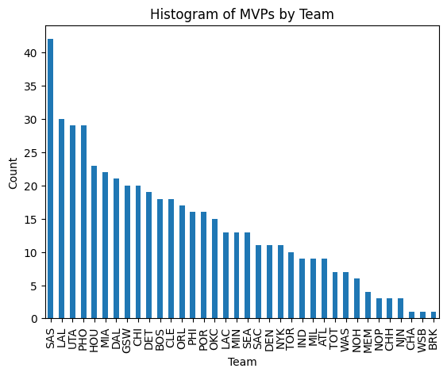

```python
mvps['Tm'].value_counts().plot(kind='bar')

plt.xlabel('Team')
plt.ylabel('Count')
plt.title('Histogram of MVPs by Team')

plt.show()
```

Am meisten MVP-Votes erhielten in den letzten rund 30 Jahren Spieler aus San Antonio.

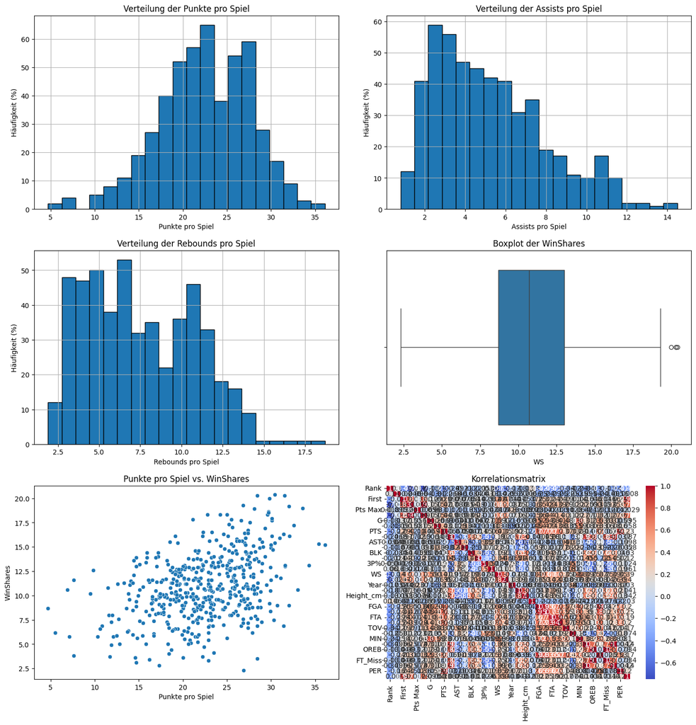

```python
# Erstellen eines 3x2 Grids für die Plots
fig, axs = plt.subplots(3, 2, figsize=(15, 15))  # Größe kann nach Bedarf angepasst werden

# Anpassung des Layouts für eine bessere Anzeige
plt.tight_layout(pad=4.0)

# Histogramm der Punkte pro Spiel
mvps['PTS'].hist(bins=20, edgecolor='black', ax=axs[0, 0])
axs[0, 0].set_title('Verteilung der Punkte pro Spiel')
axs[0, 0].set_xlabel('Punkte pro Spiel')
axs[0, 0].set_ylabel('Häufigkeit (%)')

# Histogramm der Assists pro Spiel
mvps['AST'].hist(bins=20, edgecolor='black', ax=axs[0, 1])
axs[0, 1].set_title('Verteilung der Assists pro Spiel')
axs[0, 1].set_xlabel('Assists pro Spiel')
axs[0, 1].set_ylabel('Häufigkeit (%)')

# Histogramm der Rebounds pro Spiel
mvps['TRB'].hist(bins=20, edgecolor='black', ax=axs[1, 0])
axs[1, 0].set_title('Verteilung der Rebounds pro Spiel')
axs[1, 0].set_xlabel('Rebounds pro Spiel')
axs[1, 0].set_ylabel('Häufigkeit (%)')

# Boxplot zur Darstellung der Verteilung der WinShares
sns.boxplot(x='WS', data=mvps, ax=axs[1, 1])
axs[1, 1].set_title('Boxplot der WinShares')

# Scatterplot zur Visualisierung der Beziehung zwischen Punkten pro Spiel und WinShares
sns.scatterplot(x='PTS', y='WS', data=mvps, ax=axs[2, 0])
axs[2, 0].set_title('Punkte pro Spiel vs. WinShares')
axs[2, 0].set_xlabel('Punkte pro Spiel')
axs[2, 0].set_ylabel('WinShares')

# Korrelationsmatrix der numerischen Merkmale
# Auswahl nur der numerischen Spalten für die Korrelationsmatrix
numerical_cols = [col for col in mvps.columns if mvps[col].dtype != 'object' and mvps[col].dtype != 'string']
numerical_mvps = mvps[numerical_cols]
correlation_matrix = numerical_mvps.corr()
sns.heatmap(correlation_matrix, annot=True, cmap='coolwarm', ax=axs[2, 1])
axs[2, 1].set_title('Korrelationsmatrix')

plt.show()
```

Verteilung der Rebounds pro Spiel: Dieses Histogramm zeigt, wie häufig bestimmte Anzahlen von Rebounds pro Spiel vorkommen. Die Verteilung scheint breiter gestreut zu sein, mit den häufigsten Werten im Bereich von etwa 5 bis 10 Rebounds pro Spiel.

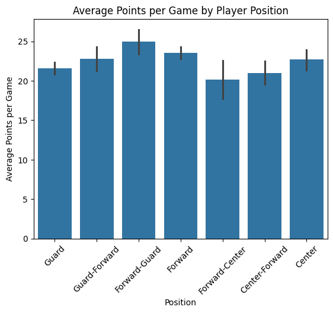

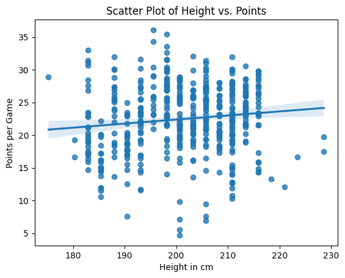

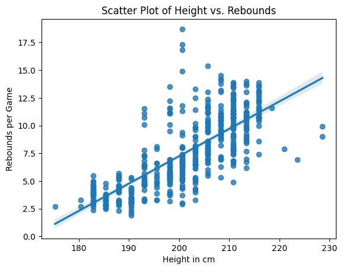

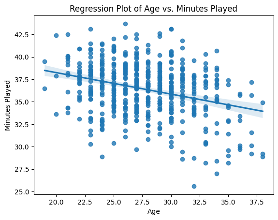

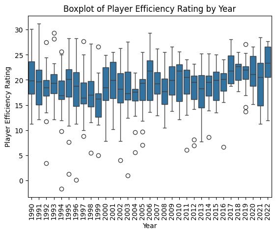

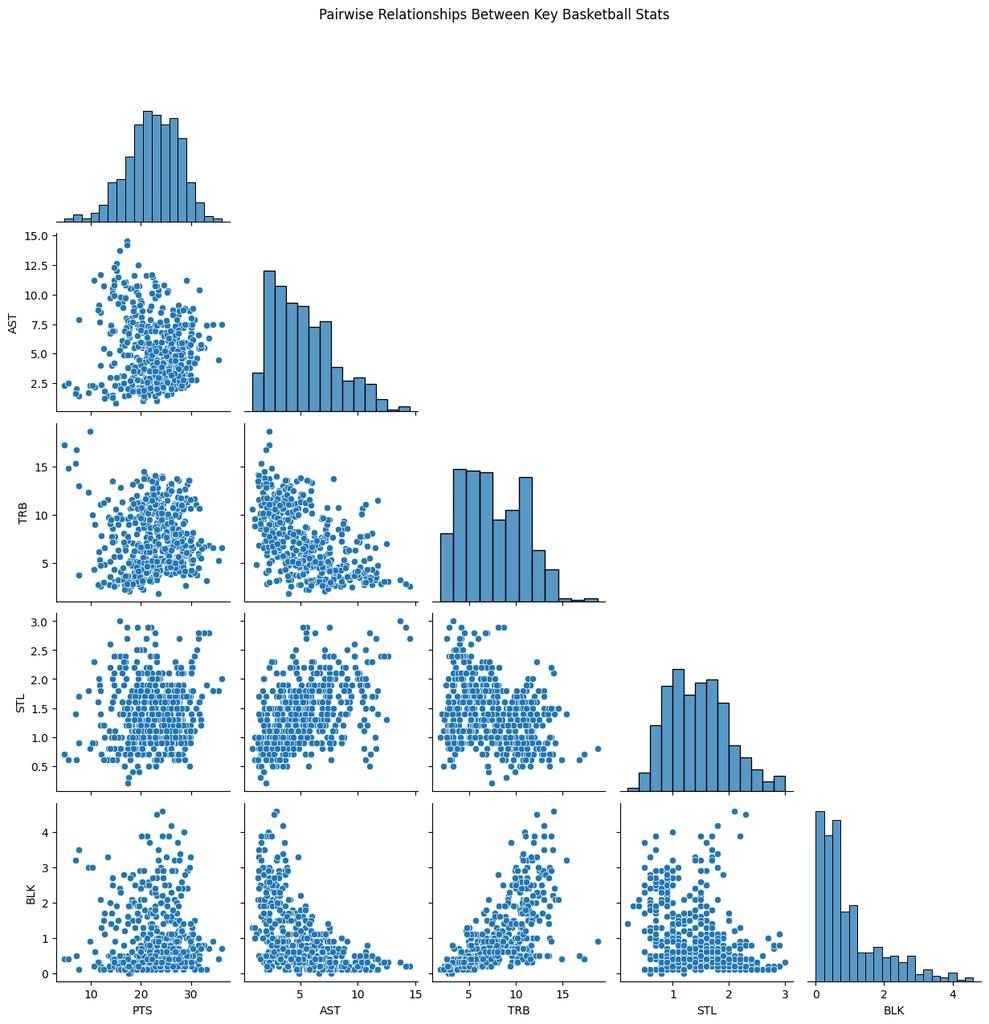

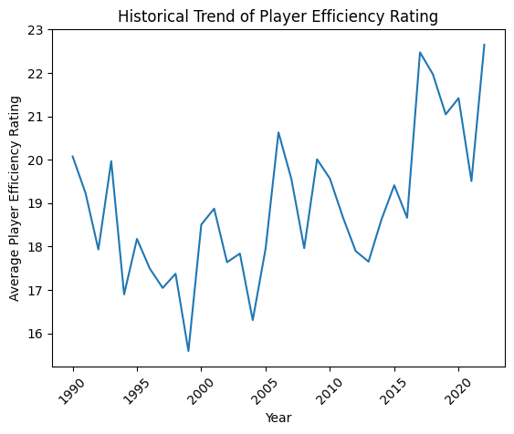

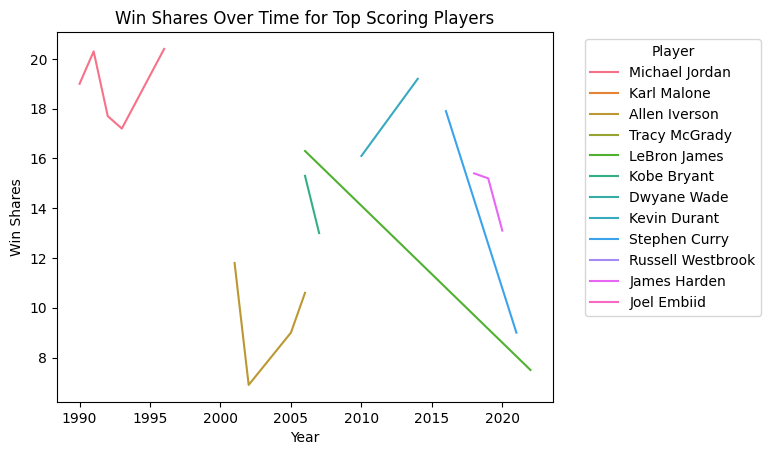

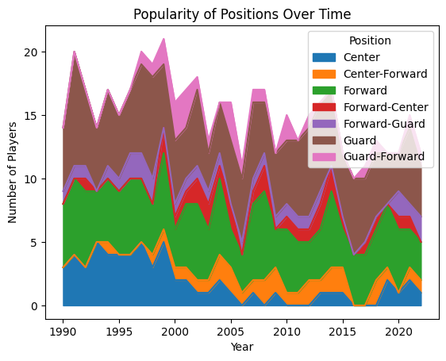

```python
# Erstellen Sie eine Reihenfolge für die Positionen, die die Spielpositionen von ballfern zu ballnah abbildet
position_order = ['Guard', 'Guard-Forward', 'Forward-Guard', 'Forward', 'Forward-Center', 'Center-Forward', 'Center']

# Plot für durchschnittliche Punkte pro Position
sns.barplot(x='Position', y='PTS', data=mvps, order=position_order)
plt.xlabel('Position')
plt.ylabel('Average Points per Game')
plt.title('Average Points per Game by Player Position')
plt.xticks(rotation=45)  # Dreht die x-Achsen-Beschriftungen, falls sie überlappen
plt.show()

sns.regplot(x='Height_cm', y='PTS', data=mvps)
plt.xlabel('Height in cm')
plt.ylabel('Points per Game')
plt.title('Scatter Plot of Height vs. Points')
plt.show()

# Scatter-Plot für die Beziehung zwischen Körpergröße und Rebounds
sns.regplot(x='Height_cm', y='TRB', data=mvps)
plt.xlabel('Height in cm')
plt.ylabel('Rebounds per Game')
plt.title('Scatter Plot of Height vs. Rebounds')
plt.show()

# Erstellen eines Regressionsplots für das Alter gegen die durchschnittliche Spielzeit
sns.regplot(x='Age', y='MP', data=mvps)
plt.xlabel('Age')
plt.ylabel('Minutes Played')
plt.title('Regression Plot of Age vs. Minutes Played')
plt.show()

# Boxplot der Spieler-Effizienz für verschiedene Jahre
sns.boxplot(x='Year', y='PER', data=mvps)
plt.xlabel('Year')
plt.ylabel('Player Efficiency Rating')
plt.xticks(rotation=90)
plt.title('Boxplot of Player Efficiency Rating by Year')
plt.show()

sns.pairplot(mvps[['PTS', 'AST', 'TRB', 'STL', 'BLK']], corner=True)
plt.suptitle('Pairwise Relationships Between Key Basketball Stats', y=1.02)
plt.show()

avg_per_by_year = mvps.groupby('Year')['PER'].mean().reset_index()
sns.lineplot(x='Year', y='PER', data=avg_per_by_year)
plt.xlabel('Year')
plt.ylabel('Average Player Efficiency Rating')
plt.title('Historical Trend of Player Efficiency Rating')
plt.xticks(rotation=45)
plt.show()

top_players = mvps[mvps['PTS'] > mvps['PTS'].quantile(0.95)]
sns.lineplot(x='Year', y='WS', hue='Player', data=top_players)
plt.xlabel('Year')
plt.ylabel('Win Shares')
plt.title('Win Shares Over Time for Top Scoring Players')
plt.legend(title='Player', bbox_to_anchor=(1.05, 1), loc='upper left')
plt.show()

position_count_by_year = mvps.groupby(['Year', 'Position']).size().unstack(fill_value=0)
position_count_by_year.plot(kind='area', stacked=True)
plt.xlabel('Year')
plt.ylabel('Number of Players')
plt.title('Popularity of Positions Over Time')
plt.legend(title='Position')
plt.show()
```

Average Points per Game by Position: Die Balkendiagramm zeigt eine gleichmässige Verteilung der durchschnittlichen Punktzahl pro Spiel über verschiedene Basketballpositionen, wobei die Position des Forward-Guards leicht höhere Werte erzielt. Die Fehlerbalken deuten auf eine gewisse Streuung der Durchschnittswerte hin, was auf eine Variabilität in den Spielerleistungen innerhalb jeder Position hindeutet. Dies könnte auf eine ausgeglichene Spielweise oder eine ähnliche Beteiligung verschiedener Positionen an der Punkteerzielung schliessen lassen.

Height vs. Points: Die Datenpunkte sind über die gesamte Grafik verteilt und zeigen eine leichte positive Tendenz, was durch die aufsteigende Regressionslinie angedeutet wird. Dies bedeutet, dass Spieler mit zunehmender Körpergrösse tendenziell leicht mehr Punkte pro Spiel erzielen, obwohl es eine grosse Streuung gibt und die Körpergrösse allein kein starker Prädiktor für die Punktzahl pro Spiel zu sein scheint.

Height vs. Rebounds: Die Regressionslinie, zeigt eine deutlichere positive Korrelation als beim vorherigen Plot: Grössere Spieler scheinen durchschnittlich mehr Rebounds pro Spiel zu erzielen. Die Steigung der Regressionslinie ist steiler, was auf einen stärkeren Zusammenhang zwischen der Körpergrösse und der Fähigkeit hinweist, Rebounds zu erlangen.

Age vs. Minutes player: Die absteigende Regressionslinie deutet auf eine negative Korrelation hin: Mit zunehmendem Alter scheinen Spieler tendenziell weniger Minuten pro Spiel zu spielen. Dies könnte darauf hindeuten, dass ältere Spieler entweder durch jüngere ersetzt werden, weniger Ausdauer haben, oder durch strategische Entscheidungen des Coaching-Staffs kürzere Spielzeiten erhalten. Die Datenpunkte sind breit gestreut, was auf eine hohe Variabilität im Verhältnis von Alter zu Spielminuten hinweist.

PER Rating per Year: Die mittleren Werte der PER scheinen über die Jahre relativ konstant zu bleiben, mit einer leichten Zunahme gegen Ende des dargestellten Zeitraums. Die Boxen zeigen, dass es eine breite Streuung von PER-Werten gibt. Die einzelnen Punkte ausserhalb der Whisker deuten auf Ausreisser hin, was auf einzelne Spieler mit ungewöhnlich hohen oder niedrigen Effizienzbewertungen hinweist. Die konstante mittlere Effizienz über die Jahre legt nahe, dass sich die Bewertungskriterien für die Effizienz nicht wesentlich verändert haben, trotz der Ausreißer, die individuelle Spitzenleistungen oder -ausfälle darstellen könnten.

Relations between Key Basketball Stats: Die Plots zeigen, dass die Verteilungen für Assists, Steals und Blocks rechtsschief sind, was bedeutet, dass die meisten Spieler niedrige Werte in diesen Statistiken haben, während einige wenige Spieler besonders hohe Werte aufweisen. Die Verteilungen von Punkten und Rebounds scheinen symmetrischer zu sein. Die Scatterplots zeigen unterschiedliche Grade der Beziehungen, mit einigen erkennbaren Mustern, wie etwa zwischen Punkten und Assists, wo eine leichte positive Korrelation zu sehen ist.

Historical Trend of PER: Points per Game by Nationality: Es gibt Schwankungen im Laufe der Zeit, aber insgesamt scheint ein allgemeiner Aufwärtstrend zu bestehen, der besonders nach 2010 auffällt. Dieser Aufwärtstrend könnte auf verschiedene Faktoren zurückzuführen sein, wie Veränderungen im Spielstil und erhöhtes Spieltempo. Die Spitzen und Täler in der Linie zeigen die Variationen von Jahr zu Jahr, wobei einige Jahre herausragende Durchschnittswerte aufweisen, was auf besonders effiziente Spieljahrgänge oder Veränderungen in den Ligastandards hinweisen könnte.

Win Shares over top scoring players: Jede Linie repräsentiert den Karriereverlauf eines Spielers und kann Aufschlüsse über deren Höhepunkte und andere signifikante Momente ihrer Karriere geben.

Popularity of Positions: Es scheint deutlich weniger Center zu geben.

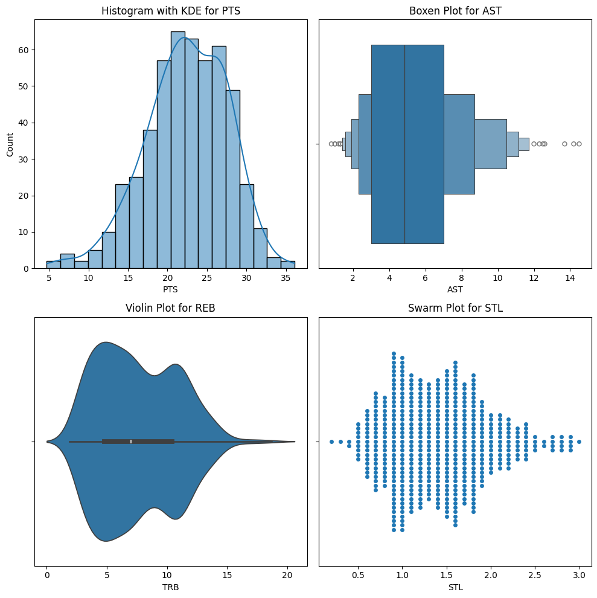

```python
fig, axs = plt.subplots(2, 2, figsize=(10, 10))

# Histogram with a fitted Kernel Density Estimate (KDE) for 'PTS'
sns.histplot(mvps['PTS'], kde=True, ax=axs[0, 0])
axs[0, 0].set_title('Histogram with KDE for PTS')

# Boxen Plot for 'AST' (Assists)
sns.boxenplot(x=mvps['AST'], ax=axs[0, 1])
axs[0, 1].set_title('Boxen Plot for AST')

# Violin Plot for 'REB' (Rebounds)
sns.violinplot(x=mvps['TRB'], ax=axs[1, 0])
axs[1, 0].set_title('Violin Plot for REB')

# Swarm Plot for 'STL' (Steals)
sns.swarmplot(x=mvps['STL'], ax=axs[1, 1])
axs[1, 1].set_title('Swarm Plot for STL')

plt.tight_layout()
plt.show()
```

Swarm Plot for STL: Dieser Plot zeigt die Verteilung der Steals (STL) pro Spiel als einzelne Punkte, die so angeordnet sind, dass sie nicht übereinander liegen. Dies bietet eine klare Sicht auf die Häufigkeit und Verteilung von Steals und deutet auf eine Konzentration der Werte im Bereich von etwa 0,5 bis 1,5 Steals pro Spiel hin.

#### (5) Verwendung eines ML Frameworks/Library (tensorflow/keras, sklearn oder im Kurs nicht betrachtete wie pytorch)

#### (6) Erstellen von Modellvorhersagen

```python
def calculate_ml_scores(df):
    """
    Calculate mutual information (MI) scores for each feature in the given dataframe.

    Parameters:
    df (pandas.DataFrame): The input dataframe containing the features and target variable.

    Returns:
    X (pandas.DataFrame): The modified dataframe with the target variable removed.
    y (pandas.Series): The target variable.
    mi_scores (pandas.Series): The MI scores for each feature, sorted in descending order.
    """
    X = df.copy()
    y = X["Share"]

    X.drop('Share', axis=1, inplace=True)

    # Label encoding for categoricals
    for colname in X.select_dtypes("object"):
        X[colname], _ = X[colname].factorize()

    # All discrete features should now have integer dtypes (double-check this before using MI!)
    discrete_features = X.dtypes == int

    mi_scores = mutual_info_regression(X, y)
    mi_scores = pd.Series(mi_scores, name="MI Scores", index=X.columns)
    mi_scores = mi_scores.sort_values(ascending=False)
    return X, y, mi_scores
```

```python
to_drop_mi = ['Rank','Player', 'MVP', 'Nationality', 'Position', 'First', 'Pts Won']
master_table_mi = mvps.copy()
master_table_mi.drop(to_drop_mi, axis=1, inplace=True)
master_table_mi = master_table_mi.fillna(0)
```

```python
X, y, mi_scores = calculate_ml_scores(df=master_table_mi)
```

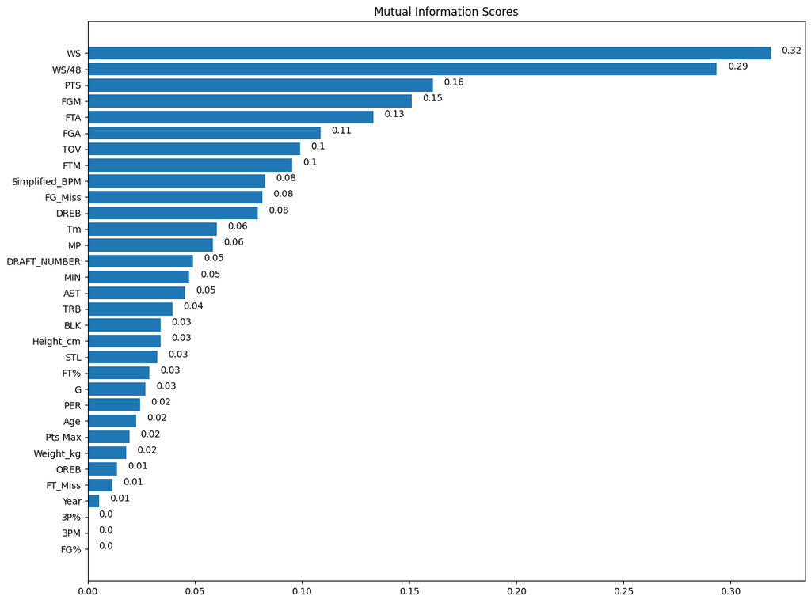

```python
import pandas as pd
import numpy as np

def plot_mi_scores(scores, figsize):
    """
    Plots the mutual information scores.
    """
    scores = scores.sort_values(ascending=True)
    width = np.arange(len(scores))
    ticks = list(scores.index)

    fig, ax = plt.subplots(figsize=figsize)
    ax.barh(width, scores)

    for index, value in enumerate(scores):
        plt.text(value +0.005 , index, str(round(value,2)))

    plt.yticks(width, ticks)
    plt.title("Mutual Information Scores")

plot_mi_scores(mi_scores, figsize=(14,11))
```

```python
# drop not needed columns
to_drop = [
    #'Year',
    '3PM',
    'OREB',
    'FG%',
    'Pts Max',
    'Age',
    '3P%',
    'PER',
    'STL',
    'Height_cm',
    'FT%',
    'Weight_kg',
    'BLK',
    'G',
    'AST',
    'MIN',
    'TRB',
    'Tm',
    'DRAFT_NUMBER',
    'MP',
    'Rank',
    'Player',
    'MVP',
    'Year',
    'Nationality',
    'Position',
    'First',
    'Pts Won',
    'FT_Miss'
]
```

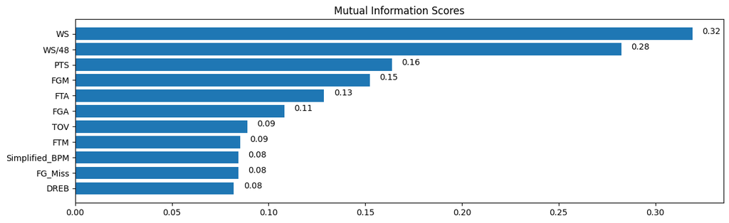

```python
mvps_mod = mvps.copy()
mvps_mod.drop(to_drop, axis=1, inplace=True)
X, y, mi_scores2 = calculate_ml_scores(df=mvps_mod)
plot_mi_scores(mi_scores2, figsize=(14,4))
```

#### Train/Test Split

test on selected year, train on all other years that weren't selected

```python
def train_test_split_by_year(year, df, scaling=False):
    """
    Splits the dataset into training and testing sets based on the specified year.

    Parameters:
    - year (int): The year to be used as the test year.
    - df (pandas.DataFrame): The dataset to be split.
    - scaling (bool): Indicates whether to perform feature scaling or not. Default is False.
    """
    train_df = df[df['Year'] != year]
    test_df = df[df['Year'] == year]

    train_df2 = train_df.copy()
    test_df2 = test_df.copy()

    train_df2.drop(to_drop, axis=1, inplace=True)
    test_df2.drop(to_drop, axis=1, inplace=True)

    if scaling == True:
        sc_X = StandardScaler()
        sc_y = StandardScaler()
        train_df2 = sc_X.fit_transform(train_df2)
        test_df2 = sc_y.fit_transform(test_df2)

    X_train = train_df2.copy()
    y_train = X_train["Share"]

    X_test = test_df2.copy()
    y_test = X_test["Share"]

    X_train.drop('Share', axis=1, inplace=True)
    cols = X_train.columns
    X_test.drop('Share', axis=1, inplace=True)

    X_train = np.array(X_train)
    y_train = np.array(y_train)
    X_test = np.array(X_test)
    y_test = np.array(y_test)

    return X_train, y_train, X_test, y_test, cols
```

#### Model Helper Functions

train, predict, calculate MAE & R squared, show actual vs. predicted in a dataframe

```python
def run_model(regressor, X_train, y_train, X_test, y_test, df, year):
    """
    Runs a regression model to predict the MVP winner in a given year.

    Parameters:
    regressor (object): The regression model object.
    X_train (array-like): The training data features.
    y_train (array-like): The training data target variable.
    X_test (array-like): The testing data features.
    y_test (array-like): The testing data target variable.
    df (DataFrame): The DataFrame containing the MVP race data.
    year (int): The year for which the MVP winner is to be predicted.

    Returns:
    tuple: A tuple containing the trained model, mean absolute error (MAE), R-squared (R2) score,
        predicted winner name, actual winner name, and the MVP race DataFrame.
    """
    model = regressor
    model.fit(X_train, y_train)
    predictions = model.predict(X_test)
    mae = mean_absolute_error(predictions, y_test)
    r2 = r2_score(y_test, predictions)

    mvp_race = df[df['Year'] == year]
    mvp_race['predicted_share'] = predictions
    mvp_race = mvp_race.sort_values(["Share", "predicted_share"], ascending = (False, False))

    actual_winner = mvp_race[mvp_race['MVP'] == 1]['Player']
    predicted_winner = mvp_race[mvp_race['predicted_share'] == mvp_race['predicted_share'].max()]['Player']

    actual_winner_name = actual_winner.iloc[0] if not actual_winner.empty else None
    predicted_winner_name = predicted_winner.iloc[0] if not predicted_winner.empty else None

    return model, mae, r2, predicted_winner_name, actual_winner_name, mvp_race
```

```python
years = list(range(1990, 2022))

def run_model_average(df, regressor, scaling=False, print_metrics=False):
    """
    Runs the model for each year in the dataset and calculates the average metrics.
    """
    mae_lst = []
    r2_lst = []
    predicted_lst = []
    actual_lst = []
    label_lst =[]
    model_lst = []
    for year in years:
        X_train, y_train, X_test, y_test, cols = train_test_split_by_year(year=year, df=df, scaling=False)
        model, mae, r2, predicted_winner, actual_winner, mvp_race = run_model(regressor,
        X_train,
        y_train,
        X_test,
        y_test,
        df=df,
        year=year
        )
        label = 'correct' if predicted_winner == actual_winner else 'incorrect'
        mae_lst.append(mae)
        r2_lst.append(r2)
        predicted_lst.append(predicted_winner)
        actual_lst.append(actual_winner)
        label_lst.append(label)
        model_lst.append(model)
    d = {
    'year': years,
    'MAE': mae_lst,
    'R squared': r2_lst,
    'Predicted MVP': predicted_lst,
    'Actual MVP': actual_lst,
    'Label': label_lst
    }
    print('d=', d)
    summary = pd.DataFrame(d)
    correct_count = summary['Label'].value_counts().iloc[0]
    incorrect_count = summary['Label'].value_counts().iloc[1]
    accuracy = correct_count / (correct_count + incorrect_count)
    avg_mae = summary['MAE'].mean()
    avg_r2  = summary['R squared'].mean()

    if print_metrics == True:
        print(f"Average MAE: {avg_mae}")
        print(f"Average R squared: {avg_r2}")
        print(f"Prediction accuracy: {accuracy}")
    return avg_mae, avg_r2, accuracy, summary, model_lst, cols
```

find average metrics and overall accuracy

```python
pd.options.mode.chained_assignment = None

lr_avg_mae, lr_avg_r2, lr_accuracy, lr_summary, lr_models, cols = run_model_average(df=mvps,
    regressor = LinearRegression(),
    scaling=True,
    print_metrics=True)
```

```
d= {'year': [1990, 1991, 1992, 1993, 1994, 1995, 1996, 1997, 1998, 1999, 2000, 2001, 2002, 2003, 2004, 2005, 2006, 2007, 2008, 2009, 2010, 2011, 2012, 2013, 2014, 2015, 2016, 2017, 2018, 2019, 2020, 2021], 'MAE': [0.16531810970776278, 0.13313439917652417, 0.10810313892341396, 0.14657041970842855, 0.…
Average MAE: 0.1565872290289235
Average R squared: 0.45506556162149514
Prediction accuracy: 0.59375
```

Random Forest Regressor

```python
#display feature importance for tree algorithms (RF, XGB, LGBM
def avg_feature_importance(models, cols):
    """
    Calculate the average feature importance scores for a list of models.
    """
    lst = []
    for model in models:
        feature_importance = list(model.feature_importances_)
        lst.append(feature_importance)

    df = pd.DataFrame(lst, columns=cols)
    mean_features = df.mean()

    df2 = pd.DataFrame([cols ,mean_features]).T
    df2 = df2.rename(columns={0:'Feature', 1:'Score'}).sort_values(by='Score', ascending=False)

    plt.title('Feature Importance Score')
    sns.barplot(x='Score',
                y= 'Feature',
                data=df2,
                )
    plt.show()
```

```python
rf_avg_mae, rf_avg_r2, rf_accuracy, rf_summary, rf_models, rf_cols = run_model_average(df=mvps,
    regressor=RandomForestRegressor(n_estimators = 23,
                                                random_state = 0,
                                                max_depth=7,
                                                min_samples_leaf=1,
                                                min_samples_split=2),
                                                print_metrics=True)
```

```
d= {'year': [1990, 1991, 1992, 1993, 1994, 1995, 1996, 1997, 1998, 1999, 2000, 2001, 2002, 2003, 2004, 2005, 2006, 2007, 2008, 2009, 2010, 2011, 2012, 2013, 2014, 2015, 2016, 2017, 2018, 2019, 2020, 2021], 'MAE': [0.14324924794036448, 0.08468297023077336, 0.08018892280440784, 0.16786249062002878, 0.…
Average MAE: 0.13055621831149805
Average R squared: 0.4634973037904911
Prediction accuracy: 0.5625
```

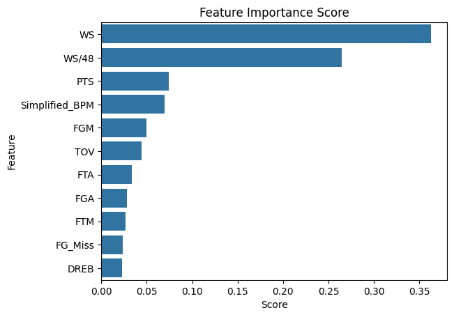

```python
avg_feature_importance(models=rf_models, cols=rf_cols)
```

#### Forecast this Seasons MVP

Get Data

WS/48 not yet available for this Season, so it needs to be dropped!

```python
# Fetch player stats for the current season (replace '2023-24' if necessary)
player_stats = leaguedashplayerstats.LeagueDashPlayerStats(season='2023-24')


# Get a DataFrame of the stats
df_player_stats = player_stats.get_data_frames()[0]
df_player_stats = df_player_stats[df_player_stats['GP'] >= 65] #Players must have played at least 65 Games to be considered beginning this season


df_player_stats['TRB'] = df_player_stats['OREB'] + df_player_stats['DREB']
df_player_stats['TRB'] = pd.to_numeric(df_player_stats['TRB'], errors='coerce')
df_player_stats['Simplified_BPM'] = ((df_player_stats['PTS'] + 0.5 * df_player_stats['TRB'] + df_player_stats['AST'] + 2 * (df_player_stats['STL'] + df_player_stats['BLK'])
                          - (df_player_stats['FGA'] - df_player_stats['FGM']) - 0.5 * (df_player_stats['FTA'] - df_player_stats['FTM']) - df_player_stats['TOV']) / (df_player_stats['MIN']/df_player_stats['GP']))



df_player_stats['FT_Miss'] = df_player_stats['FTA'] - df_player_stats['FTM']
df_player_stats['FG_Miss'] = df_player_stats['FGA'] - df_player_stats['FGM']


# Specify the columns you need, based on the mutual information scores chart
selected_columns = [
    'PLAYER_NAME',
    'PTS',  # Points
    'W_PCT',  # Field Goals Made
    'FGA',  # Field Goals Attempted
    'FGM',  # Three Point Field Goals Made, if available
    'FTA',  # Three Point Field Goals Attempted, if available
    'FTM',  # Free Throws Made
    'TOV',  # Turnovers
    'DREB',  # Offensive Rebounds
    'Simplified_BPM',
    'FG_Miss'
]

# Filter the DataFrame to only include the selected columns
df_selected_stats = df_player_stats[selected_columns]
# Display the DataFrame with the selected columns
print(df_selected_stats.head())
#print(df_player_stats['Simplified_BPM'])
```

```
      PLAYER_NAME  PTS  W_PCT  FGA  FGM  FTA  FTM  TOV  DREB  Simplified_BPM  \
3    Aaron Gordon  985  0.676  704  388  261  170  104   293       37.957499
4   Aaron Holiday  487  0.487  396  175   59   54   50    96       31.165485
5   Aaron Nesmith  854  0.571  624  307  131  101   64   204       33.313132
6   Aaron Wiggins  509  0.697  357  199   66   52   55   119       38.674589
10     Al Horford  562  0.785  419  214   30   26   48   331       32.933446

    FG_Miss
3       316
4       221
5       317
6       158
10      205
```

```python
def prep_train_test(df):

    forecast_X_train_df = df.copy()
    forecast_X_train_df.drop(to_drop, axis=1, inplace=True)
    forecast_y_train_df = forecast_X_train_df['Share']
    forecast_X_train_df.drop(['Share'], axis=1, inplace=True)


    forecast_X_test_df = df_selected_stats_cleaned

    print(f'Training dataset columns: \n{list(forecast_X_train_df.columns)} \n')
    print(f'Forecasting dataset columns: \n{list(forecast_X_test_df.columns)}')
    return forecast_X_train_df, forecast_y_train_df, forecast_X_test_df
```

```python
def fit_forecast_model(regressor):
    model = regressor
    model.fit(forecast_X_train_df, forecast_y_train_df)
    predictions = model.predict(forecast_X_test_df)

    mvp_race_forecast = df_selected_stats.copy()
    mvp_race_forecast['Share Prediction'] = predictions
    mvp_race_forecast = mvp_race_forecast.sort_values(["Share Prediction"], ascending = (False))

    mvp_race_forecast_sub = mvp_race_forecast[[
                                                'Player',
                                                'Share Prediction',
                                                'WS',
                                                'PTS',
                                                'Simplified_BPM',
                                                'TOV',
                                                'FGM',
                                                'FTA',
                                                'FTM',
                                                'FG_Miss',
                                                'DREB'
                                              ]].reset_index(drop=True)
    mvp_race_forecast_sub.head()
    avg_feature_importance(models=[model], cols=df_selected_stats_cleaned.columns)
    return model, mvp_race_forecast_sub
```

```python
def show_highlighted_df(df):
    return df.style.highlight_max(subset = [        'WS',
                                                    'PTS',
                                                    'Simplified_BPM',
                                                    'TOV',
                                                    'FGM',
                                                    'FTA',
                                                    'FTM',
                                                    'FG_Miss',
                                                    'DREB',
                                                    'Share Prediction'], color = 'lightgreen', axis = 0)
```

```python
mvps2 = mvps.copy()
mvps2.drop('WS/48', axis=1, inplace=True)
df_selected_stats.rename(columns={'W_PCT': 'WS'}, inplace=True)
df_selected_stats.rename(columns={'PLAYER_NAME': 'Player'}, inplace=True)

needed_cols = ['PTS', 'WS', 'FGA', 'FGM', 'FTA', 'FTM', 'TOV', 'DREB', 'Simplified_BPM', 'FG_Miss']
df_selected_stats_cleaned = df_selected_stats[list(needed_cols)]


forecast_X_train_df, forecast_y_train_df, forecast_X_test_df = prep_train_test(df=mvps2)
```

```
Training dataset columns:
['PTS', 'WS', 'FGA', 'FGM', 'FTA', 'FTM', 'TOV', 'DREB', 'Simplified_BPM', 'FG_Miss']

Forecasting dataset columns:
['PTS', 'WS', 'FGA', 'FGM', 'FTA', 'FTM', 'TOV', 'DREB', 'Simplified_BPM', 'FG_Miss']
```

#### (8) Korrekte Interpretation der Modellergebnisse und Modellgütemasse

```python
n_estimator_lst = [11,12,13,14,15,16]
max_depth_lst = [10,11,12]
min_samples_leaf_lst = [1]
min_samples_split_lst = [2]

def find_best_parameter_rf(df):
    avg_mae_lst = []
    avg_r2_lst = []
    avg_accuracy_lst = []
    summary_lst = []

    ex_n_estimator_lst = []
    ex_max_depth_lst = []
    ex_min_samples_leaf_lst = []
    ex_min_samples_split_lst = []

    for i in n_estimator_lst:
        for j in max_depth_lst:
            for x in min_samples_leaf_lst:
                for y in min_samples_split_lst:
                    mae, r2, accuracy, summary, models, cols = run_model_average(df=df,
                        regressor=RandomForestRegressor(n_estimators = i,
                                                    random_state = 0,
                                                    max_depth=j,
                                                    min_samples_leaf=x,
                                                    min_samples_split=y
                                                    ),
                print_metrics=False)
                    avg_mae_lst.append(mae)
                    avg_r2_lst.append(r2)
                    avg_accuracy_lst.append(accuracy)
                    summary_lst.append(summary)

                    ex_n_estimator_lst.append(i)
                    ex_max_depth_lst.append(j)
                    ex_min_samples_leaf_lst.append(x)
                    ex_min_samples_split_lst.append(y)

    d = {
        'n_estimator': ex_n_estimator_lst,
        'max_depth': ex_max_depth_lst,
        'min_samples_leaf': ex_min_samples_leaf_lst,
        'min_samples_split': ex_min_samples_split_lst,
        'MAE': avg_mae_lst,
        'r2': avg_r2_lst,
        'Accuracy': avg_accuracy_lst,
    }

    #sort by highest accuracy, then highest r squared
    df = pd.DataFrame(d).sort_values(["Accuracy", "r2"], ascending = (False, False))
    return df
```

```python
rf_parameter_options = find_best_parameter_rf(df=mvps)
```

[output not shown]

```python
rf_parameter_options.head()
```

|  | n_estimator | max_depth | min_samples_leaf | min_samples_split | MAE | r2 | Accuracy |
| --- | --- | --- | --- | --- | --- | --- | --- |
| 11 | 14 | 12 | 1 | 2 | 0.131804 | 0.463944 | 0.59375 |
| 8 | 13 | 12 | 1 | 2 | 0.132367 | 0.457989 | 0.59375 |
| 16 | 16 | 11 | 1 | 2 | 0.132733 | 0.449952 | 0.59375 |
| 9 | 14 | 10 | 1 | 2 | 0.131796 | 0.448703 | 0.59375 |
| 10 | 14 | 11 | 1 | 2 | 0.133657 | 0.446457 | 0.59375 |

```python
rf_best_parameters = dict(rf_parameter_options.iloc[0][:5])
rf_best_parameters
```

```
{'n_estimator': 14.0,
 'max_depth': 12.0,
 'min_samples_leaf': 1.0,
 'min_samples_split': 2.0,
 'MAE': 0.1318039474927431}
```

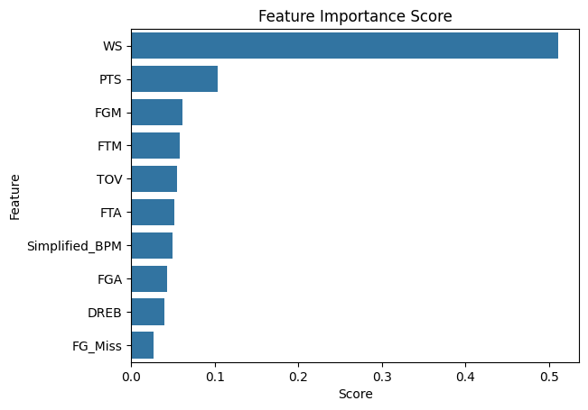

```python
#best random forest model
rf_model, rf_mvp_race_forecast = fit_forecast_model(regressor = RandomForestRegressor(
                                                    n_estimators = 14,
                                                    random_state = 42,
                                                    max_depth=11,
                                                    min_samples_leaf=1,
                                                    min_samples_split=2)
)
```

```python
show_highlighted_df(df=rf_mdvp_race_forecast.head(10))
```

|  | Player | Share Prediction | WS | PTS | Simplified_BPM | TOV | FGM | FTA | FTM | FG_Miss | DREB |
| --- | --- | --- | --- | --- | --- | --- | --- | --- | --- | --- | --- |
| 0 | Nikola Jokic | 0.467736 | 0.701000 | 2048 | 78.047953 | 230 | 806 | 433 | 354 | 581 | 737 |
| 1 | Domantas Sabonis | 0.435381 | 0.563000 | 1550 | 62.816089 | 266 | 618 | 405 | 283 | 422 | 809 |
| 2 | Anthony Davis | 0.405500 | 0.581000 | 1810 | 65.166175 | 152 | 689 | 495 | 404 | 555 | 705 |
| 3 | Anthony Edwards | 0.385893 | 0.688000 | 2022 | 51.324803 | 233 | 711 | 492 | 410 | 828 | 369 |
| 4 | Damian Lillard | 0.384786 | 0.667000 | 1759 | 47.076092 | 191 | 539 | 501 | 461 | 724 | 281 |
| 5 | LeBron James | 0.381381 | 0.565000 | 1757 | 55.794458 | 233 | 661 | 387 | 289 | 568 | 441 |
| 6 | Luka Doncic | 0.380248 | 0.657000 | 2370 | 65.583985 | 282 | 804 | 608 | 478 | 848 | 588 |
| 7 | Aaron Gordon | 0.374143 | 0.676000 | 985 | 37.957499 | 104 | 388 | 261 | 170 | 316 | 293 |
| 8 | Brandin Podziemski | 0.374143 | 0.556000 | 670 | 32.493419 | 87 | 266 | 79 | 50 | 320 | 296 |
| 9 | Royce O'Neale | 0.374143 | 0.468000 | 598 | 32.674181 | 72 | 211 | 33 | 23 | 318 | 312 |

Gemäss dem MVP-TRacker von Basketballreference (https://www.basketball-reference.com/friv/mvp.html) wurde der erste Platz korrekt von unserem Modell hervogesagt. Interessant ist dass die PLätze 8-10 von unserem Modell nicht auf dem Modell von Baskteballreference vertreten sind, dies wird daran liegen, dass ihre Share Prediction hoch ist und dies vom Modell stark gewichtet wird.

Würden wir das Projekt nochmals machen, würden wir uns mehr auf die sogenannten advanced stats fokusieren als auf die basics wie PTS, STL, BLK etc. Wichtige advanced Stats könnten gemäss REcherchen die folgenden sein: Assists per game, Box Plus/Minus, Field goals attempted per game, Total rebounds per game, Team win percentage, Win shares, Win shares per 48 minutes und Record.

XGB

```python
#Commented because it take 23 minutes
'''
n_estimator_lst = [3, 6, 9, 12, 15, 18]
max_depth_lst = [3, 6, 9, 12]
learning_rate_lst = [0.01, 0.05, 0.1, 0.2]
subsample_lst = [0.5, 0.8, 1]
colsample_bytree_lst = [0.5, 0.7, 1]


def find_best_parameter_xgb(df):
    avg_mae_lst = []
    avg_r2_lst = []
    avg_accuracy_lst = []
    summary_lst = []

    ex_n_estimator_lst = []
    ex_max_depth_lst = []
    ex_learning_rate_lst = []
    ex_subsample = []
    ex_colsample_bytree = []

    for i in n_estimator_lst:
        for j in max_depth_lst:
            for k in learning_rate_lst:
                for a in subsample_lst:
                    for b in colsample_bytree_lst:
                        mae, avg_r2, accuracy, summary, models, cols = run_model_average(
                                                                    df=df,
                                                                    regressor = XGBRegressor(n_estimators=i,
                                                                                            max_depth=j,
                                                                                            learning_rate=k,
                                                                                            subsample=a,
                                                                                            colsample_bytree=b),
                                                                    scaling=False)
                        avg_mae_lst.append(mae)
                        avg_r2_lst.append(avg_r2)
                        avg_accuracy_lst.append(accuracy)
                        summary_lst.append(summary)

                        ex_n_estimator_lst.append(i)
                        ex_max_depth_lst.append(j)
                        ex_learning_rate_lst.append(k)
                        ex_subsample.append(a)
                        ex_colsample_bytree.append(b)

    d = {
        'n_estimator': ex_n_estimator_lst,
        'max_depth': ex_max_depth_lst,
        'learning_rate': ex_learning_rate_lst,
        'subsample': ex_subsample,
        'colsample_bytree': ex_colsample_bytree,
        'MAE': avg_mae_lst,
        'r2': avg_r2_lst,
        'Accuracy': avg_accuracy_lst,
    }

    #sort by highest accuracy, then highest r squared
    df = pd.DataFrame(d).sort_values(["Accuracy", "r2"], ascending = (False, False))
    return df
'''
```

```
'\nn_estimator_lst = [3, 6, 9, 12, 15, 18]\nmax_depth_lst = [3, 6, 9, 12]\nlearning_rate_lst = [0.01, 0.05, 0.1, 0.2]\nsubsample_lst = [0.5, 0.8, 1]\ncolsample_bytree_lst = [0.5, 0.7, 1]\n\n\ndef find_best_parameter_xgb(df): \n    avg_mae_lst = []\n    avg_r2_lst = []\n    avg_accuracy_lst = []\n   …
```

```python
#xgb_parameter_options = find_best_parameter_xgb(df=mvps)
```

```python
'''
xgb_best_parameters = dict(xgb_parameter_options.iloc[0][:5])
xgb_best_parameters
'''
```

```
'\nxgb_best_parameters = dict(xgb_parameter_options.iloc[0][:5])\nxgb_best_parameters\n'
```

```python
from xgboost import XGBRegressor

xgb_avg_mae, xgb_avg_r2, xgb_accuracy, xgb_summary, xgb_models, xgb_cols = run_model_average(df=mvps,
                regressor = XGBRegressor(n_estimators=3, max_depth=3, learning_rate = 0.2, subsample=1, colsample_bytree=0.5),
                scaling=False, print_metrics=True)
```

```
d= {'year': [1990, 1991, 1992, 1993, 1994, 1995, 1996, 1997, 1998, 1999, 2000, 2001, 2002, 2003, 2004, 2005, 2006, 2007, 2008, 2009, 2010, 2011, 2012, 2013, 2014, 2015, 2016, 2017, 2018, 2019, 2020, 2021], 'MAE': [0.15346345502563885, 0.14251378447115423, 0.12762126316743738, 0.19555823753987042, 0.…
Average MAE: 0.16821481456029347
Average R squared: 0.3385190261494708
Prediction accuracy: 0.6875
```

```python
xgb_summary
```

|  | year | MAE | R squared | Predicted MVP | Actual MVP | Label |
| --- | --- | --- | --- | --- | --- | --- |
| 0 | 1990 | 0.153463 | 0.425351 | Michael Jordan | Magic Johnson | incorrect |
| 1 | 1991 | 0.142514 | 0.522531 | Michael Jordan | Michael Jordan | correct |
| 2 | 1992 | 0.127621 | 0.511286 | Michael Jordan | Michael Jordan | correct |
| 3 | 1993 | 0.195558 | 0.219053 | Michael Jordan | Charles Barkley | incorrect |
| 4 | 1994 | 0.159325 | 0.349023 | David Robinson | Hakeem Olajuwon | incorrect |
| 5 | 1995 | 0.140493 | 0.494043 | David Robinson | David Robinson | correct |
| 6 | 1996 | 0.125718 | 0.530225 | Michael Jordan | Michael Jordan | correct |
| 7 | 1997 | 0.141426 | 0.444936 | Karl Malone | Karl Malone | correct |
| 8 | 1998 | 0.157818 | 0.287779 | Karl Malone | Michael Jordan | incorrect |
| 9 | 1999 | 0.158782 | 0.064500 | Karl Malone | Karl Malone | correct |
| 10 | 2000 | 0.114215 | 0.509683 | Shaquille O'Neal | Shaquille O'Neal | correct |
| 11 | 2001 | 0.202213 | -0.001132 | Shaquille O'Neal | Allen Iverson | incorrect |
| 12 | 2002 | 0.170296 | 0.255473 | Tim Duncan | Tim Duncan | correct |
| 13 | 2003 | 0.179622 | 0.269286 | Tracy McGrady | Tim Duncan | incorrect |
| 14 | 2004 | 0.166675 | 0.280510 | Kevin Garnett | Kevin Garnett | correct |
| 15 | 2005 | 0.191220 | -0.049377 | Dirk Nowitzki | Steve Nash | incorrect |
| 16 | 2006 | 0.167563 | 0.254549 | Dirk Nowitzki | Steve Nash | incorrect |
| 17 | 2007 | 0.170204 | 0.205889 | Dirk Nowitzki | Dirk Nowitzki | correct |
| 18 | 2008 | 0.180402 | 0.339629 | Chris Paul | Kobe Bryant | incorrect |
| 19 | 2009 | 0.192402 | 0.397412 | LeBron James | LeBron James | correct |
| 20 | 2010 | 0.165277 | 0.475022 | LeBron James | LeBron James | correct |
| 21 | 2011 | 0.187480 | 0.174707 | LeBron James | Derrick Rose | incorrect |
| 22 | 2012 | 0.182704 | 0.274300 | LeBron James | LeBron James | correct |
| 23 | 2013 | 0.140974 | 0.539503 | LeBron James | LeBron James | correct |
| 24 | 2014 | 0.165368 | 0.472250 | Kevin Durant | Kevin Durant | correct |
| 25 | 2015 | 0.165093 | 0.531409 | Stephen Curry | Stephen Curry | correct |
| 26 | 2016 | 0.223240 | 0.242297 | Stephen Curry | Stephen Curry | correct |
| 27 | 2017 | 0.235729 | 0.193862 | Russell Westbrook | Russell Westbrook | correct |
| 28 | 2018 | 0.175767 | 0.413521 | James Harden | James Harden | correct |
| 29 | 2019 | 0.164414 | 0.479359 | Giannis Antetokounmpo | Giannis Antetokounmpo | correct |
| 30 | 2020 | 0.169491 | 0.290086 | Giannis Antetokounmpo | Giannis Antetokounmpo | correct |
| 31 | 2021 | 0.169808 | 0.435641 | Nikola Jokić | Nikola Jokić | correct |

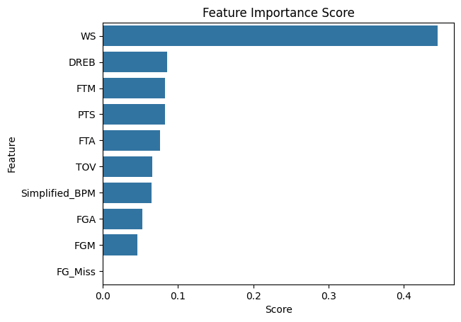

```python
xgb_model, xgb_mvp_race_forecast = fit_forecast_model(regressor = XGBRegressor(
                                            n_estimators=16,
                                            max_depth=5,
                                            learning_rate=0.2745))
```

```python
def visualize_shap_values(mvp_race, model):
    top_candidates = list(mvp_race.head(3)['Player'])

    for idx, player in enumerate(top_candidates):
        data_for_prediction = mvp_race[mvp_race['Player'] == player]
        data_for_prediction = data_for_prediction[list(xgb_cols)]
        data_for_prediction_array = data_for_prediction.values.reshape(1, -1)
        rank = idx + 1
        print(f"Rank: {rank}: {player}")

        # Create object that can calculate shap values
        explainer = shap.TreeExplainer(model)
        # Calculate Shap values
        shap_values = explainer.shap_values(data_for_prediction_array)
        shap.initjs()
        display(shap.force_plot(explainer.expected_value, shap_values, data_for_prediction))
```

```python
forecast_tables = [xgb_mvp_race_forecast, rf_mvp_race_forecast]
model_names = ['XGBoost','Random Forest']

tables = []
for name, forecast_table in zip(model_names, forecast_tables):
    player_sub = forecast_table.head(3)[['Player']]
    player_sub['Rank'] = ['1st Place','2nd Place','3rd Place']
    player_sub2 = player_sub.T.reset_index(drop=True)
    player_sub2.columns = player_sub2.iloc[1]
    player_sub2.drop(player_sub2.tail(1).index,inplace=True)

    share_sub = forecast_table.head(3)[['Share Prediction']]
    share_sub['Rank'] = ['1st Place Share','2nd Place Share','3rd Place Share']

    share_sub2 = share_sub.T.reset_index(drop=True)
    share_sub2.columns = share_sub2.iloc[1]
    share_sub2.drop(share_sub2.tail(1).index,inplace=True)

    merged_df = pd.concat([player_sub2, share_sub2], axis=1).sort_index(axis=1)
    merged_df['Model'] = name

    tables.append(merged_df)

final_summary_table = pd.concat(tables)
# shift column 'Name' to first position
first_column = final_summary_table.pop('Model')
# first_column) function
final_summary_table.insert(0, 'Model', first_column)
```

```python
final_summary_table
```

| 1 | Model | 1st Place | 1st Place Share | 2nd Place | 2nd Place Share | 3rd Place | 3rd Place Share |
| --- | --- | --- | --- | --- | --- | --- | --- |
| 0 | XGBoost | Nikola Jokic | 0.52654 | Domantas Sabonis | 0.47564 | Jeremy Sochan | 0.322723 |
| 0 | Random Forest | Nikola Jokic | 0.467736 | Domantas Sabonis | 0.435381 | Anthony Davis | 0.4055 |

1. und 2. Plätze bei beiden Modellen gleich